# Data Wrangling

## Introduction

#### The Amazon Unlocked Mobile Phones dataset was downloaded from [here](https://www.kaggle.com/PromptCloudHQ/amazon-reviews-unlocked-mobile-phones/data). Before uploading this file into R, dplyr and tidyr packages were installed.

```r
library(dplyr)
library(tidyr)
```

```r
library(ggplot2)
```

#### The dataset consists of around 400K records and includes the following fields: Product Name, Brand Name, Price, Rating, Reviews, and Review Votes.

```r
glimpse(amz)
```

```
## Observations: 413,840
## Variables: 6
## $ Product.Name <fctr> "CLEAR CLEAN ESN" Sprint EPIC 4G Galaxy SPH-D700...
## $ Brand.Name   <fctr> Samsung, Samsung, Samsung, Samsung, Samsung, Sam...
## $ Price        <dbl> 199.99, 199.99, 199.99, 199.99, 199.99, 199.99, 1...
## $ Rating       <int> 5, 4, 5, 4, 4, 1, 2, 2, 5, 3, 3, 5, 5, 1, 5, 2, 5...
## $ Reviews      <fctr> I feel so LUCKY to have found this used (phone t...
## $ Review.Votes <int> 1, 0, 0, 0, 0, 1, 0, 0, 0, 0, 0, 0, 2, 1, 1, 0, 6...
```

#### The following commands helped to see how the dataset looks like and what intofrmation it contains.

```r
amz<-tbl_df(amz)
View(amz)
```

## Step 1. Checking for missing values.

#### As the first step, the following comands were used to check if there were anu missing values in the dataset.

```r
amz%>%
count(Product.Name=="")
```

```
## # A tibble: 1 x 2
##   `Product.Name == ""`      n
##                  <lgl>  <int>
## 1                FALSE 413840
```

```r
amz%>%
count(Brand.Name=="")
```

```
## # A tibble: 2 x 2
##   `Brand.Name == ""`      n
##                <lgl>  <int>
## 1              FALSE 348669
## 2               TRUE  65171
```

```r
amz%>%
count(Price=="")
```

```
## # A tibble: 2 x 2
##   `Price == ""`      n
##           <lgl>  <int>
## 1         FALSE 407907
## 2            NA   5933
```

```r
amz%>%
count(Rating=="")
```

```
## # A tibble: 1 x 2
##   `Rating == ""`      n
##            <lgl>  <int>
## 1          FALSE 413840
```

```r
amz%>%
count(Reviews=="")
```

```
## # A tibble: 2 x 2
##   `Reviews == ""`      n
##             <lgl>  <int>
## 1           FALSE 413778
## 2            TRUE     62
```

```r
amz%>%
count(Review.Votes=="")
```

```
## # A tibble: 2 x 2
##   `Review.Votes == ""`      n
##                  <lgl>  <int>
## 1                FALSE 401544
## 2                   NA  12296
```

#### There were no missing values indetified in Product Name and Rating columns. The only sufficent numbers of missing values were found in the following fields: Brand Name and Review Votes.It will be shown further how certain brand names were substituted by using their corresponding product names. Also, Price contained a small amount of missing values. However, the aproach, introduced below, that focuses on analyzing only the most important products, will help to filter these products out automatically and they will not influence the analysis results.

## Step 2. Filtering out core products/brands.

#### The next step was to find out how many unique products exist in this dataset. The following command produced the results showing that originally there were 4410 products in the dataset.

```r
#count number of products, n=4410
amz %>%
count(Product.Name)
```

```
## # A tibble: 4,410 x 2
##                                                                   Product.Name
##                                                                         <fctr>
##  1                                    'ATT Wireless LG CU720 Shine for in Red'
##  2 "\"CLEAR CLEAN ESN\" Sprint EPIC 4G Galaxy SPH-D700*FRONT CAMERA*ANDROID*SL
##  3 "\"Nokia Asha 302 Unlocked GSM Phone with 3.2MP Camera, Video, QWERTY Keybo
##  4   ((Unlocked))BlackBerry Bold 9650 Unlocked Clean ESN Smartphone non camera
##  5 "(LANDVO) 5.0\" Capacitive Touch MTK6582 Quad Core Android 4.2.2 3G Phone 5
##  6 "[XMAS DEAL] [New Edition] Jethro [SC213V2] Flip Quad-band Unlocked GSM Sen
##  7 [XMAS DEAL] Jethro [SC118] Simple Unlocked Quad-band GSM Senior & Kids Cell
##  8 10.6'' Inch E-passion Unlocked Smart Phone +Tablet='' Phablet'' Android 4.4
##  9 "2.45 \" IPS Touch Screen the World's Smallest Android Smartphone Dual Sim
## 10 "2.45\" UNLOCKED Rugged Micro Android Smart Phone; Dual-Sim, WiFi, and Blue
## # ... with 4,400 more rows, and 1 more variables: n <int>
```

#### However, taking into account that Amazon was interested in the performance of only core products, it was important to define which of these 4410 products represent its core portfolio. The assumption is that the distribution of revenue among products with reviews is reflective of total Amazon sales of the unlocked mobile phones. So the next step was to calculate the revenue per product based on price and quantity (the number of times the product appeared in the dataset) and its share of revenue. After that all products were sorted by the share of revenue with the most important products at the top of the dataset. The following code was used for these calculations.

```r
#calculate revenue per product
pr<-amz %>%
 group_by(Product.Name) %>%
 summarise(revenue=sum(Price),cnt = n())%>%
 arrange(desc(revenue))

#calculate total revenue
total_revenue<- pr %>%
filter(!is.na(revenue)) %>%
summarise(total_revenue=sum(revenue))

#calculate revenue share, %
pr<-pr %>%
mutate(revenue_share=revenue/92540701*100)

#calculate cumulative revenue share,%
pr<-pr %>%
mutate(cum_revenue_share=cumsum(revenue_share))
```

#### The results showed that n=1074 products, which equals 24% of the total number of products, were responsible for generating around 90% of the total revenue. Apart from the business goal, another reason for selecting just the top performing products was analytical - the comlexity of this dataset and the Product Name, in particular. Product Name is an important field that will be used for deriving product features and as it was demonstrated above, its naming doesn’t follow the same standards that would allow to decompose it into separate fields very easy. Thus, it was decided to focus all the efforts and further analysis on the top ~1000 well performing products. Using the follwing command, the top performing products were filtered out from the original dataset.

```r
#select products that bring ~90% of revenue
top90<-pr %>%
filter (cum_revenue_share<90)
```

#### The list of top 1000 products was merged with the original dataset and the rest of the fileds were appended: Brand Name, Price, Rating, and Reviews. Also, the unnecessary fields were then removed from the combined dataset. Ulimately, the final list of the core products was created and the overall number of records decreased from ~400K to ~300K.

```r
#append Brand.Name, Price, Rating, Reviews to the list of products (n=1074, 24%) that bring ~90% of revenue)
amz_top90<-right_join(amz, top90)
#exclude certain fields
amz_top90<-amz_top90%>%
select(-revenue,-cnt,-revenue_share,-cum_revenue_share)

glimpse(amz_top90)
```

```
## Observations: 318,596
## Variables: 6
## $ Product.Name <fctr> BLU Studio 5.0 C HD - Unlocked Cell Phones - Ret...
## $ Brand.Name   <fctr> BLU, BLU, BLU, BLU, BLU, BLU, BLU, BLU, BLU, BLU...
## $ Price        <dbl> 2000, 2000, 2000, 2000, 2000, 2000, 2000, 2000, 2...
## $ Rating       <int> 5, 5, 5, 1, 5, 4, 5, 5, 5, 5, 5, 4, 4, 5, 4, 5, 5...
## $ Reviews      <fctr> I can not say alot about this phone because I bo...
## $ Review.Votes <int> 2, 0, 0, 1, 0, 0, 0, 0, 2, 1, 0, 0, 0, 0, 0, 0, 0...
```

## Step 3.Cleaning up the brand name.

#### The summary of products by brand name revealed that there were around 50K of records with the missing values, certain amount of the unknowns, specific brands related to the non-phone categories (such as smartwatch, accessories, etc.), and different spelling of the same brand name.

```r
#group by brands
amz_top90%>%
count(Brand.Name)%>%
as.data.frame()
```

```
##                                     Brand.Name     n
## 1                                              52337
## 2                                      Alcatel  1150
## 3  Amazon.com, LLC *** KEEP PORules ACTIVE ***   783
## 4                                        Apple 55013
## 5                                         Asus  1053
## 6                                         ASUS   230
## 7                               ASUS Computers   719
## 8                                   Blackberry   328
## 9                                   BlackBerry 14452
## 10                                         BLU 49895
## 11                                       Casio   942
## 12                                  CAT PHONES    31
## 13                                       CNPGD 10998
## 14                                        FIGO   336
```

[output cut: 35 more lines]

#### The original brand name variations were substituted by the corresponding brand names

```r
#clean Brand.Name
amz_top90<-amz_top90 %>%
mutate(Brand.Name.Clean=case_when(Brand.Name=="Amazon.com, LLC *** KEEP PORules ACTIVE ***" ~ "Apple",
Brand.Name %in% (c("Asus","ASUS","ASUS Computers")) ~ "Asus",
Brand.Name %in% (c("Blackberry","BlackBerry")) ~ "Blackberry",
Brand.Name %in% (c("Global Services","Samssung","samsung","Samsung","SAMSUNG","Samsung international","Samsung Korea","Samsung Korea LTD","PowerMoxie","Unknown")) ~ "Samsung",
Brand.Name %in% (c("GreatCall", "Jitterbug")) ~ "GreatCall",
Brand.Name %in% (c("LG","LG Electronics","LG Electronics MobileComm USA")) ~ "LG",
Brand.Name %in% (c("Moto X","Motorola")) ~ "Motorola",
Brand.Name %in% (c("Huawei","HUAWEI")) ~ "Huawei",
TRUE ~ as.character(Brand.Name)))
```

## Step 4. Replacing the missing brand values.

#### As it was shown above, there were around 50K of cases with the missing brand name. It was decided to use the product name to create the corresponding brand name.

```r
#fill in the missing brand names, keep other categories (smartwatch, adapter, case, etc.) missing, and exclude them
amz_top90<-amz_top90 %>%
mutate(Brand.Name.Clean=case_when(Brand.Name.Clean!="" ~ Brand.Name.Clean,
grepl('Apple',Product.Name,fixed=TRUE) ~ 'Apple',
grepl('Samsung',Product.Name,fixed=TRUE) ~ 'Samsung',
grepl('Lenovo',Product.Name,fixed=TRUE) ~ 'Lenovo',
grepl('ASUS',Product.Name,fixed=TRUE) ~ 'Asus',
grepl('BlackBerry',Product.Name,fixed=TRUE) ~ 'Blackberry',
grepl('Blackberry',Product.Name,fixed=TRUE) ~ 'Blackberry',
grepl('BLU',Product.Name,fixed=TRUE) ~ 'BLU',
grepl('ECOOPRO',Product.Name,fixed=TRUE) ~ 'ECOOPRO',
grepl('Hipipoo',Product.Name,fixed=TRUE) ~ 'Hipipoo',
grepl('Honor',Product.Name,fixed=TRUE) ~ 'Huawei',
grepl('HTC',Product.Name,fixed=TRUE) ~ 'HTC',
grepl('Huawei',Product.Name,fixed=TRUE) ~ 'Huawei',
grepl('IPHONE',Product.Name,fixed=TRUE) ~ 'Apple',
grepl('LG',Product.Name,fixed=TRUE) ~ 'LG',
grepl('Microsoft',Product.Name,fixed=TRUE) ~ 'Microsoft',
grepl('Moto',Product.Name,fixed=TRUE) ~ 'Motorola',
grepl('Motorola',Product.Name,fixed=TRUE) ~ 'Motorola',
grepl('Nextbit',Product.Name,fixed=TRUE) ~ 'Nextbit',
grepl('Nokia',Product.Name,fixed=TRUE) ~ 'Nokia',
grepl('Oneplus',Product.Name,fixed=TRUE) ~ 'OnePlus',
grepl('Pantech',Product.Name,fixed=TRUE) ~ 'Pantech',
grepl('POSH MOBILE',Product.Name,fixed=TRUE) ~ 'Posh Mobile',
grepl('Posh Mobile',Product.Name,fixed=TRUE) ~ 'Posh Mobile',
grepl('Sony',Product.Name,fixed=TRUE) ~ 'Sony',
grepl('SONY',Product.Name,fixed=TRUE) ~ 'Sony',
grepl('Google',Product.Name,fixed=TRUE) ~ 'Google',
TRUE ~ Brand.Name.Clean))

#fix the brand name for Nexus models
amz_top90<-amz_top90 %>%
mutate(Brand.Name.Clean= replace(Brand.Name.Clean, grepl('Nexus',Product.Name,fixed=TRUE), "Google"))
```

#### The brands that represented other categories (smartwatch, case, adapter, etc.) were excluded from the analysis. It was done by filtering out only brands that were relevant for further analysis. Ulimately, the original list of 49 brands was decreased to 30 most relevant brand names.

```r
#exclude brands/categories that are not phones
amz_top90<-amz_top90%>%
filter(Brand.Name.Clean %in% (c("Alcatel","Apple","Asus","Blackberry","BLU","Casio","CAT PHONES","ECOOPRO","FIGO","Google","GreatCall","Hipipoo","HTC","Huawei","Lenovo","LG","Mango Natural","Microsoft","Motorola","Nextbit","Nokia","OnePlus","Pantech","Polaroid","Posh Mobile","RCA","Samsung","Sony","Star","ZTE")))

#group by cleaned brand name
amz_top90%>%
count(Brand.Name.Clean)%>%
as.data.frame()
```

```
##    Brand.Name.Clean     n
## 1           Alcatel  1150
## 2             Apple 71490
## 3              Asus  2134
## 4        Blackberry 16349
## 5               BLU 50830
## 6             Casio   942
## 7        CAT PHONES    31
## 8           ECOOPRO   497
## 9              FIGO   336
## 10           Google  9001
## 11        GreatCall   806
## 12          Hipipoo    84
## 13              HTC  8905
## 14           Huawei  3947
```

[output cut: 16 more lines]

## Step 5. Looking for price outliers.

#### The next data wragling step was to look for potential outliers in the dataset. First, the Summary command below helped to identify that there were no products with zero or negative prices.

```r
#summary of price
summary(amz_top90$Price)
```

```
##    Min. 1st Qu.  Median    Mean 3rd Qu.    Max.
##   20.99   99.99  179.99  267.71  319.99 2408.73
```

#### The minimum price of $20.99 seemed reasonable for its corresponding basic phone model. However, the maximum price of $2408.73 seemed strange. Thus, products with extemely large prices were considered to be outliers. The following commands were used to calcualte the average price and the standard deviation.

```r
#mean_price
mean_price<- amz_top90 %>%
summarise(mean_price=mean(Price))

#standard deviation
sd_price<- amz_top90 %>%
summarise(sd_price=sd(Price))

#filter potential outliers
Outliers<-amz_top90%>%
filter(Price>(mean(Price)+3*sd(Price)))

#count the number of records per each price
Outliers%>%
count(Price)
```

```
## # A tibble: 7 x 2
##     Price     n
##     <dbl> <int>
## 1 1157.00   119
## 2 1300.00    13
## 3 2000.00  4993
## 4 2066.00    14
## 5 2224.00   111
## 6 2252.00    39
## 7 2408.73    26
```

```r
#outlier - if Price more than $1300
amz_top90<-amz_top90%>%
mutate(Outlier=ifelse(Price>(1300),1,0))

#group outliers by product name - 26 products were considered to be outliers
amz_top90%>%
filter(Outlier==1)%>%
count(Product.Name)%>%
as.data.frame()
```

```
##                                                                                                                                                               Product.Name
## 1                                                                                                                          Apple iPhone 6 Plus 128GB Silver Verizon 4G LTE
## 2                                                                                                                                             Blu LIFE 8 Unlocked (Yellow)
## 3                                                                                                                  BLU Life 8 XL Smartphone - Unlocked - Global GSM - Pink
## 4                                                                                                     BLU Studio 5.0 C HD - Unlocked Cell Phones - Retail Packaging - Blue
## 5                                                                                                                       BLU Studio 5.0 C HD Smartphone - Unlocked - Yellow
## 6                                                                                                                            BLU Studio 5.0 C HD Unlocked Cellphone, White
## 7                                                                          BLU Studio 5.0C 1.3 GHz Dual Core, Android 4.4 KK, 4G HSPA+ with 5MP Camera - Unlocked (Orange)
## 8                                                                                                                     BLU Studio Selfie - Smartphone - GSM Unlocked - Grey
## 9                                   Lenovo S8 S898T 5.3 Inch IPS Smart Cell Phone Android 4.2 MTK6589 Quad Core 1.5GHz RAM 1GB+ROM 8GB GSM Dual SIM 1280x720 13MP (Silver)
## 10 Lenovo S820 HD4.7 Inch Unlocked Android Smartphone - (1280X720) MTK6589 Quad Core 1.2GHz 1GB RAM Android 4.2 2MP/13MP AF LED Flash IPS GPS TF-White(Rooted+Google Play)
## 11                                                                     Lenovo S960 VIBE X Smartphone 5.0 Inch FHD Screen MTK6589T 1.5GHz 2GB 16GB 6.9mm Ultrathin - Silver
## 12                Lenovo Vibe Shot / Z90-7 Unlocked 5 inch IPS TFT Screen Android OS 5.0 Phone, MSM8939 Octa Core, RAM: 3G ROM: 32G, Dual SIM, FDD-LTE 4G Smartphone Black
## 13                                                                                          Lenovo VIBE X S960 IdeaPhone 5" 1080P 13MP Quad-Core Unlocked Smartphone Phone
## 14                                                     Lenovo VIBE Z2 5.5 inch Android 4.4 Smart Phone,Qualcomm Snapdragon410 Quad Core 1.2GHz, RAM: 2GB, ROM: 32GB, White
```

[output cut: 39 more lines]

```r
#exclude outliers
amz_top90<-amz_top90%>%
filter(Outlier==0)
```

#### Since those outliers were excluded from the dataset, it was necessary to recalculate each product’s share of revenue and the cumulative revenue of the remaining core products.

```r
#calculate revenue per product
amz_clean<-amz_top90 %>%
group_by(Product.Name) %>%
summarise(Revenue=sum(Price),cnt = n())%>%
arrange(desc(Revenue))

#calculate revenue share, %
amz_clean<-amz_clean %>%
mutate(Revenue_Share=Revenue/92540701*100)

#calculate cumulative revenue share,%
amz_clean<-amz_clean %>%
mutate(Cum_Revenue_Share=cumsum(Revenue_Share))
```

#### Lastly, the updated dataset with the revenue information was merged with the list containing other product information.

```r
#append Brand.Name, Price, Rating, Reviews to the final list of products(n=1028, 23%) that bring 78% of revenue
amz_clean<-right_join(amz_top90, amz_clean)
glimpse(amz_clean)
```

```
## Observations: 302,471
## Variables: 12
## $ Product.Name      <fctr> BLU Studio 6.0 Unlocked Cellphone, White, B...
## $ Brand.Name        <fctr> BLU, BLU, BLU, BLU, BLU, BLU, BLU, BLU, BLU...
## $ Price             <dbl> 971.6, 971.6, 971.6, 971.6, 971.6, 971.6, 97...
## $ Rating            <int> 1, 5, 1, 5, 1, 2, 5, 1, 4, 1, 1, 1, 4, 1, 1,...
## $ Reviews           <fctr> did not recieve data on this phone had to r...
## $ Review.Votes      <int> 0, 0, 0, 0, 0, 0, 0, 0, 0, 1, 0, 1, 0, 1, 0,...
## $ Brand.Name.Clean  <chr> "BLU", "BLU", "BLU", "BLU", "BLU", "BLU", "B...
## $ Outlier           <dbl> 0, 0, 0, 0, 0, 0, 0, 0, 0, 0, 0, 0, 0, 0, 0,...
## $ Revenue           <dbl> 660688, 660688, 660688, 660688, 660688, 6606...
## $ cnt               <int> 680, 680, 680, 680, 680, 680, 680, 680, 680,...
## $ Revenue_Share     <dbl> 0.7139432, 0.7139432, 0.7139432, 0.7139432, ...
## $ Cum_Revenue_Share <dbl> 0.7139432, 0.7139432, 0.7139432, 0.7139432, ...
```

#### The final dataset consists of the core 1028 products (23% of the initial portfolio) that produced 78% of the total revenue. This ratio corresponds to the 80/20 Pareto rule. Thus, all the data wrangling manipulations above helped to remove the long tail of products, less important for the total revenue and to decrease the number of cases to ~300K.

## Step 6. Deriving product features.

#### After the list of the core products was identified, the next step was to decompose Product Name and to derive product features. The way each product is described is not the same. So various regular expressions were needed to be able to identify the following features: CPU, Battery, RAM, Storage, Rugged (waterproof/dust- or shockresistant), Camera, Color, Locked/Unlocked, Phone type, Processor Speed, Connectivity, Warranty, OS, Sim, Carrier, Certified Refurbished, Version, Screen). Below is an example of a code used to derive Camera.

```
regex="(.*)\\b([0-9.]+\\s*M(?:ega)?P(?:ixel)?)\\b(.*)"
amz_clean_features<-amz_clean_features %>%
mutate(Feature.Camera=case_when(grepl(regex, Features.Txt, ignore.case=TRUE) ~ gsub(regex,"\\2",Features.Txt, ignore.case=TRUE),
                                              TRUE ~ '')) %>%
mutate(Features.Txt=gsub(regex,"\\1 \\3",Features.Txt, ignore.case=TRUE))
```

```r
str (amz_clean_features)
```

```
## Classes 'tbl_df', 'tbl' and 'data.frame':    302471 obs. of  31 variables:
##  $ Product.Name     : Factor w/ 4410 levels "'ATT Wireless LG CU720 Shine for in Red'",..: 967 967 967 967 967 967 967 967 967 967 ...
##  $ Brand.Name       : Factor w/ 385 levels "","Acer","Aeku",..: 35 35 35 35 35 35 35 35 35 35 ...
##  $ Price            : num  972 972 972 972 972 ...
##  $ Rating           : int  1 5 1 5 1 2 5 1 4 1 ...
##  $ Reviews          : Factor w/ 162492 levels "","''''''', TURKCE, ENGLISHThis Brand New Samsung Galaxy S6 Edge G925 64GB White Factory Unlocked GSM Phone comes "| __truncated__,..: 17238 115105 133163 92811 144585 129158 49285 81197 120809 44344 ...
##  $ Review.Votes     : int  0 0 0 0 0 0 0 0 0 1 ...
##  $ Brand.Name.Clean : chr  "BLU" "BLU" "BLU" "BLU" ...
##  $ Outlier          : num  0 0 0 0 0 0 0 0 0 0 ...
##  $ Revenue          : num  660688 660688 660688 660688 660688 ...
##  $ cnt              : int  680 680 680 680 680 680 680 680 680 680 ...
##  $ Revenue_Share    : num  0.714 0.714 0.714 0.714 0.714 ...
##  $ Cum_Revenue_Share: num  0.714 0.714 0.714 0.714 0.714 ...
##  $ Features.Txt     : chr  "BLU Studio 6.0" "BLU Studio 6.0" "BLU Studio 6.0" "BLU Studio 6.0" ...
##  $ Feature.CPU      : chr  "      " "      " "      " "      " ...
```

[output cut: 17 more lines]

#### After deriving the product features, the following commands were used to identify how many mising records each field contained. Color, Locked/Unlocked, Storage, Phone Type, and Connectivity are the features available in at least every second record.

```r
#checking for missing values in product feature fields
amz_clean_features%>%
count(Feature.CPU=="")
```

```
## # A tibble: 2 x 2
##   `Feature.CPU == ""`      n
##                 <lgl>  <int>
## 1               FALSE  20550
## 2                TRUE 281921
```

```r
amz_clean_features%>%
count(Feature.Battery=="")
```

```
## # A tibble: 2 x 2
##   `Feature.Battery == ""`      n
##                     <lgl>  <int>
## 1                   FALSE   5704
## 2                    TRUE 296767
```

```r
amz_clean_features%>%
count(Feature.Ram=="")
```

```
## # A tibble: 2 x 2
##   `Feature.Ram == ""`      n
##                 <lgl>  <int>
## 1               FALSE   8574
## 2                TRUE 293897
```

```r
amz_clean_features%>%
count(Feature.Storage=="")
```

```
## # A tibble: 2 x 2
##   `Feature.Storage == ""`      n
##                     <lgl>  <int>
## 1                   FALSE 189005
## 2                    TRUE 113466
```

```r
amz_clean_features%>%
count(Feature.Rugged=="")
```

```
## # A tibble: 2 x 2
##   `Feature.Rugged == ""`      n
##                    <lgl>  <int>
## 1                  FALSE   1125
## 2                   TRUE 301346
```

```r
amz_clean_features%>%
count(Feature.Camera=="")
```

```
## # A tibble: 2 x 2
##   `Feature.Camera == ""`      n
##                    <lgl>  <int>
## 1                  FALSE  51284
## 2                   TRUE 251187
```

```r
amz_clean_features%>%
count(Feature.Color =="")
```

```
## # A tibble: 2 x 2
##   `Feature.Color == ""`      n
##                   <lgl>  <int>
## 1                 FALSE 287480
## 2                  TRUE  14991
```

```r
amz_clean_features%>%
count(Feature.Lock=="")
```

```
## # A tibble: 2 x 2
##   `Feature.Lock == ""`      n
##                  <lgl>  <int>
## 1                FALSE 243553
## 2                 TRUE  58918
```

```r
amz_clean_features%>%
count(Feature.Type=="")
```

```
## # A tibble: 2 x 2
##   `Feature.Type == ""`      n
##                  <lgl>  <int>
## 1                FALSE 223691
## 2                 TRUE  78780
```

```r
amz_clean_features%>%
count(Feature.Mhz=="")
```

```
## # A tibble: 2 x 2
##   `Feature.Mhz == ""`      n
##                 <lgl>  <int>
## 1               FALSE   1921
## 2                TRUE 300550
```

```r
amz_clean_features%>%
count(Feature.Conn=="")
```

```
## # A tibble: 2 x 2
##   `Feature.Conn == ""`      n
##                  <lgl>  <int>
## 1                FALSE 152216
## 2                 TRUE 150255
```

```r
amz_clean_features%>%
count(Feature.Warranty=="")
```

```
## # A tibble: 2 x 2
##   `Feature.Warranty == ""`      n
##                      <lgl>  <int>
## 1                    FALSE  64540
## 2                     TRUE 237931
```

```r
amz_clean_features%>%
count(Feature.Os=="")
```

```
## # A tibble: 2 x 2
##   `Feature.Os == ""`      n
##                <lgl>  <int>
## 1              FALSE  56688
## 2               TRUE 245783
```

```r
amz_clean_features%>%
count(Feature.Sim=="")
```

```
## # A tibble: 2 x 2
##   `Feature.Sim == ""`      n
##                 <lgl>  <int>
## 1               FALSE  25613
## 2                TRUE 276858
```

```r
amz_clean_features%>%
count(Feature.Carrier=="")
```

```
## # A tibble: 2 x 2
##   `Feature.Carrier == ""`      n
##                     <lgl>  <int>
## 1                   FALSE  50517
## 2                    TRUE 251954
```

```r
amz_clean_features%>%
count(Feature.Used=="")
```

```
## # A tibble: 2 x 2
##   `Feature.Used == ""`      n
##                  <lgl>  <int>
## 1                FALSE  18792
## 2                 TRUE 283679
```

```r
amz_clean_features%>%
count(Feature.Screen=="")
```

```
## # A tibble: 2 x 2
##   `Feature.Screen == ""`      n
##                    <lgl>  <int>
## 1                  FALSE  35708
## 2                   TRUE 266763
```

# Exploratory Analysis

#### First, we start the exploratory analysis by looking at the distributions. The distribution of Rating is left-skewed, with almost 60% of records having an excellent rating of 5. This indicates that regardless of phone brand, price, features, customer experience, the majority of customers tend to be very happy with their purchase at Amazon. Still there is some portion of customers who are not satisfied, reflected by their lower ratings - 3,2,1. Thus, it makes sense to investigate further what might be those reasons for dissatisfaction.

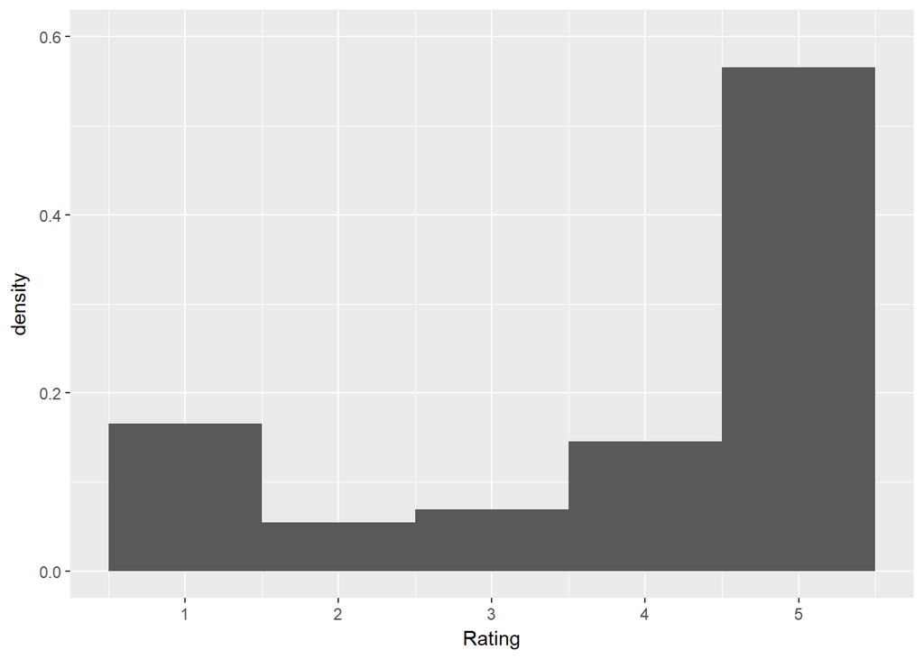

```r
#Distribution of Rating
ggplot (amz_clean_features, aes(x=Rating))+
geom_histogram(aes(y=..density..),binwidth=1)+ylim(0.0,0.6)
```

#### Distribution of Price is inverse to the distribution of ratings. It’s right-skewed with the majority of phones being sold for less than $300.

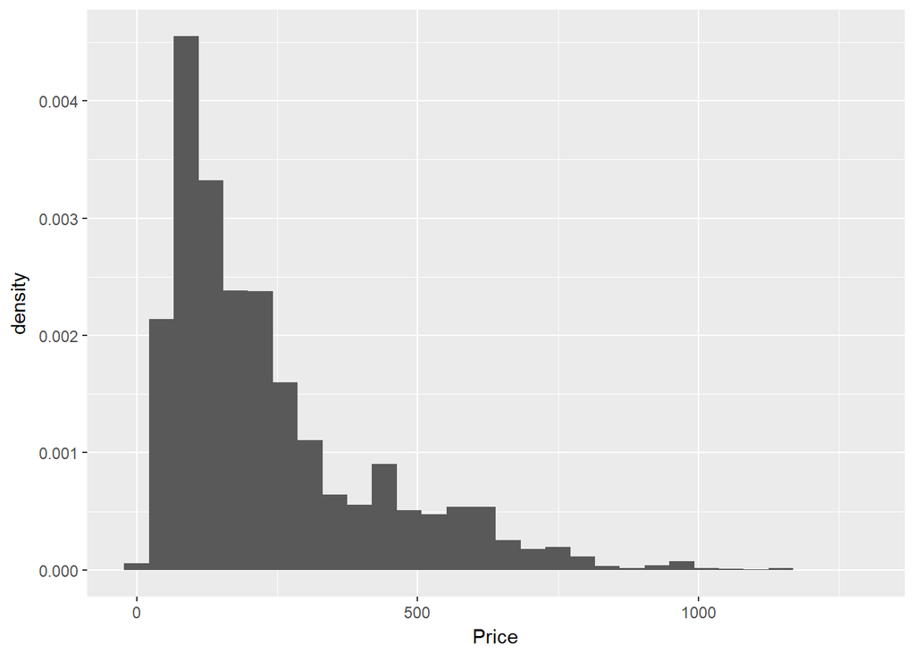

```r
#Distribution of Price
ggplot (amz_clean_features, aes(x=Price))+
geom_histogram(aes(y=..density..))
```

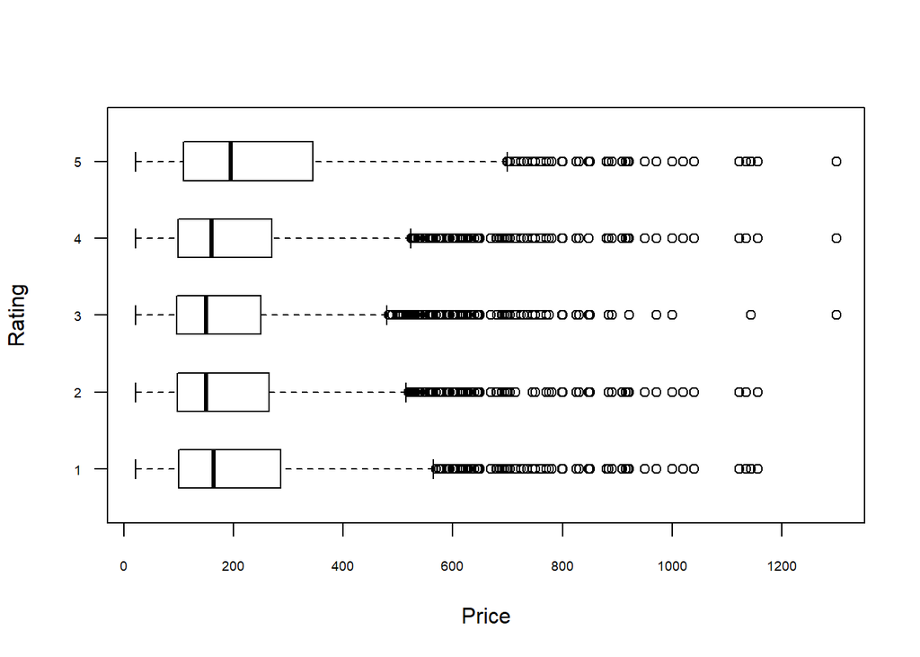

```r
#Distribution of Price over Rating
boxplot(Price~Rating, data=amz_clean_features, boxwex = 0.5,horizontal = TRUE, las = 1, cex.axis = 0.6, xlab="Price", ylab="Rating")
```

#### In order to explore the relationship, we look at the scatterplot of Rating vs. Price. It seems that there are slightly more observations with higher prices in the area with higher ratings and vice versa, but the chart is very overplotted to be able to understand what’s going on.

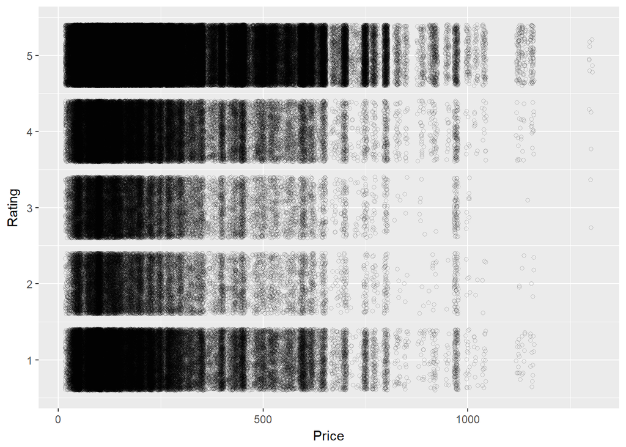

```r
#Scatterplot - Rating vs. Price
ggplot(amz_clean_features, aes(y=Rating, x=Price))+
geom_jitter(alpha=0.2, shape=1, width=5)
```

#### The reason for that is that the current dataset contains multiple records with the same price points but with the different ratings. Let’s take a look at one product example - Apple iPhone 4 16GB (Black) - AT&T. By examining the table, we see that this product was sold 617 times where each row is a separate purchase by a different customer. This table contains the rows that are identical except the following fields: Rating, Reviews, Review.Votes. It makes sense because each purchase is unique and each customer who purchased this product had a different experience reflected in their reviews and rating scores.

```r
#Look at one product - Apple iPhone 4 16GB (Black) - AT&T
iPhone4_16GB_Black_ATT<- amz_clean_features%>%
filter (Product.Name=="Apple iPhone 4 16GB (Black) - AT&T")
View(iPhone4_16GB_Black_ATT)
```

#### Next, we run a summary for all the fields available for this product to demonstrate what we saw in the table.So brand name, price, storage, color, and carrier are the same for each purchase. There is some variability in rating and review votes.

```r
#Summary for product - Apple iPhone 4 16GB (Black) - AT&T
summary(as.factor(iPhone4_16GB_Black_ATT$Brand.Name.Clean))
```

```
## Apple
##   617
```

```r
summary(iPhone4_16GB_Black_ATT$Price)
```

```
##    Min. 1st Qu.  Median    Mean 3rd Qu.    Max.
##   208.8   208.8   208.8   208.8   208.8   208.8
```

```r
summary(iPhone4_16GB_Black_ATT$Rating)
```

```
##    Min. 1st Qu.  Median    Mean 3rd Qu.    Max.
##   1.000   2.000   4.000   3.567   5.000   5.000
```

```r
summary(iPhone4_16GB_Black_ATT$Review.Votes)
```

```
##    Min. 1st Qu.  Median    Mean 3rd Qu.    Max.    NA's
##   0.000   0.000   0.000   1.697   0.000 366.000       4
```

```r
summary(as.factor(iPhone4_16GB_Black_ATT$Feature.Storage))
```

```
## 16GB
##  617
```

```r
summary(as.factor(iPhone4_16GB_Black_ATT$Feature.Color))
```

```
## Black
##   617
```

```r
summary(as.factor(iPhone4_16GB_Black_ATT$Feature.Carrier))
```

```
## AT&T
##  617
```

#### It means if we continue to use the original dataset to find the relationships betweeen ratings and price and product features, we will be using duplicate rows which is not right. Technically, it doesn’t make sense to estimate and look for any kind of relationships between duplicate price points and ratings. Apart from this, currently Rating is presented on an interval type of scale, where each value is discrete. Even if we’re using jittering, interval type of data is not very easy to plot and to discern the relationship. Thus, if we need to understand if there is any kind of relationship between rating and price, rating and brand, rating and other product features, we should look at the different dataset where each record is unique and contains information about a specific product only once, with no duplicates. Therefore, we need to reduce the data to the product level to remove redundancy about product information. Moreover, by doing this, we’re not losing any information about the product price and features. By summarizing all fields of this dataset, we get the new dataset where each record is a separate product with its corresponding price and features. As for the rating, we take an average rating of all the ratings this product received in the original dataset. There are several reasons why we are using average rating vs. other summary statistics. Unlike median, mean is affected by all range of values. As we demonstrated above, this dataset is already very skewed towards the higher rating part of the scale. If a specific product contains several low ratings, we would like to capture that by using mean to be able to show that the rating of that product is not perfect. Second, mean allows to obtain continuous values vs. original or in case of taking median, discrete values. In fact, customer perception is not discrete and it’s the function of how the satisfaction question is asked and what points it allows customers to choose from. In this case, customers can only choose among 1,2,3,4, or 5 stars to demonstrate their satisfaction. But it does not necessarily mean that their perception is exactly 3 stars, as it might be 3.2 or 3.7, etc. Third, if we look at how Amazon.com summarizes ratings of products and showing it to customers, we’ll see that it uses mean, not median or other statistics to show the rating of the product.For example, if we look at the rating of the following product on its website [here](https://www.amazon.com/Apple-iPhone-16-GB-Black/dp/B003U6628A/ref=sr_1_1?s=wireless&ie=UTF8&qid=1511125142&sr=1-1&keywords=Apple+iPhone+4+16GB+%28Black%29+-+AT%26T), we see that it’s 3.7 out of 5 stars.

```r
#Summarize products
amz_products<-amz_clean_features%>%
    group_by(Product.Name) %>%
    summarise(avg_price = mean(Price, na.rm=TRUE),
              avg_rating = mean(Rating, na.rm=TRUE),
              brand.name.clean= max(as.character(Brand.Name.Clean), na.rm=TRUE),
              Features.Txt=max(Features.Txt, na.rm=TRUE),
              Feature.CPU=max(Feature.CPU, na.rm=TRUE),
              Feature.Battery=max(Feature.Battery, na.rm=TRUE),
              Feature.Ram=max(Feature.Ram, na.rm=TRUE),
              Feature.Storage=max(Feature.Storage, na.rm=TRUE),
              Feature.Rugged=max(Feature.Rugged, na.rm=TRUE),
              Feature.Camera=max(Feature.Camera, na.rm=TRUE),
              Feature.Color=max(Feature.Color, na.rm=TRUE),
              Feature.Lock=max(Feature.Lock, na.rm=TRUE),
              Feature.Type=max(Feature.Type, na.rm=TRUE),
              Feature.Mhz=max(Feature.Mhz, na.rm=TRUE),
              Feature.Conn=max(Feature.Conn, na.rm=TRUE),
              Feature.Warranty=max(Feature.Warranty, na.rm=TRUE),
              Feature.Sim=max(Feature.Sim, na.rm=TRUE),
              Feature.Carrier=max(Feature.Carrier, na.rm=TRUE),
              Feature.Used=max(Feature.Used, na.rm=TRUE),
              Feature.Geo=max(Feature.Geo, na.rm=TRUE),
              Feature.Screen=max(Feature.Screen, na.rm=TRUE),
              Feature.Os=max(Feature.Os, na.rm=TRUE),
              counts=n()
              )
```

#### The distribution of average ratings has the similar skeweness towards higher values as the original distribution of ratings, but now it’s closer to the normal distribution and has different min and max values.

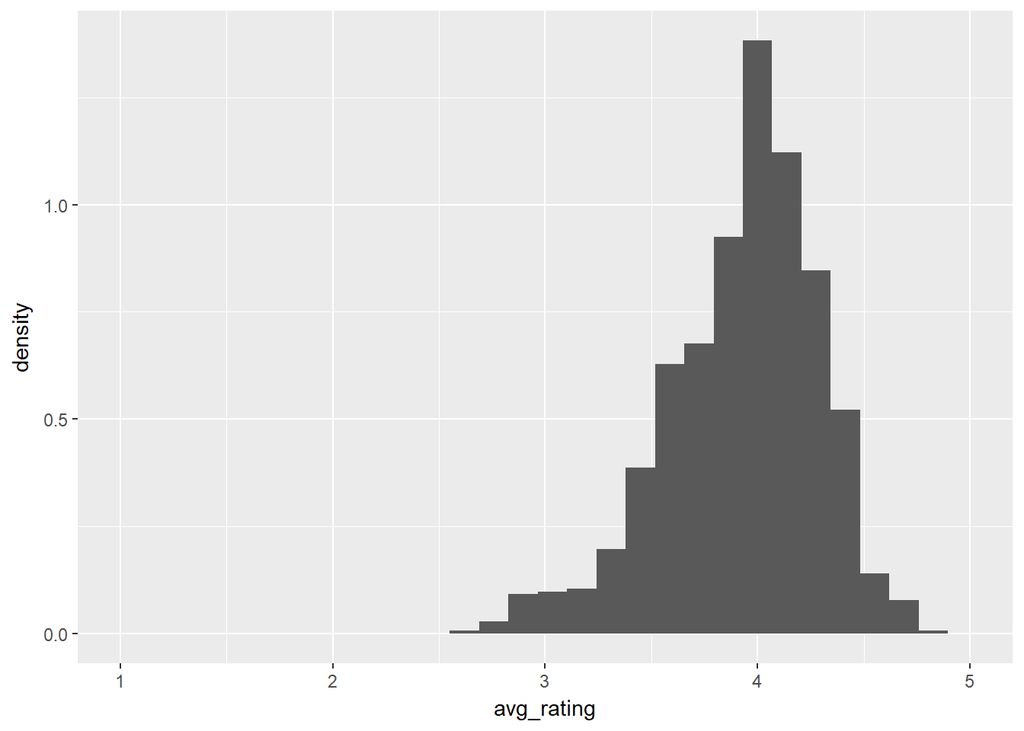

```r
#Distribution of Rating
ggplot (amz_products, aes(x=avg_rating))+
geom_histogram(aes(y=..density..))+xlim(1,5)
```

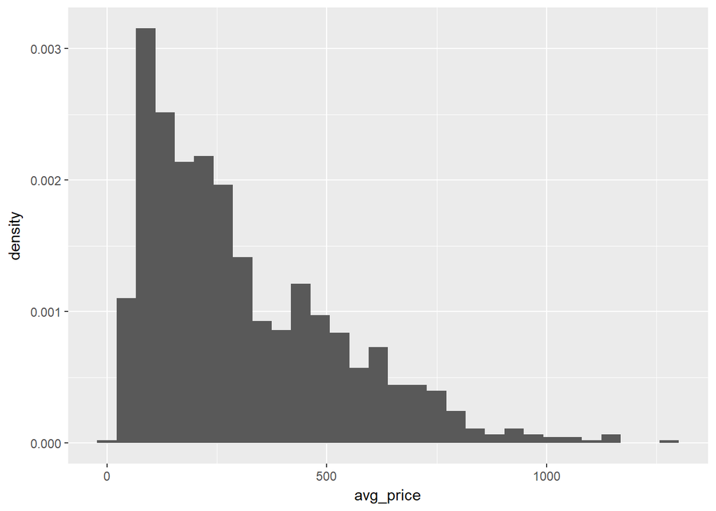

```r
#Distribution of Price
ggplot (amz_products, aes(x=avg_price))+
geom_histogram(aes(y=..density..))
```

#### Now, when the dataset is reduced to the product level, it’s easier to investigate the scatterplot of ratings vs. prices.

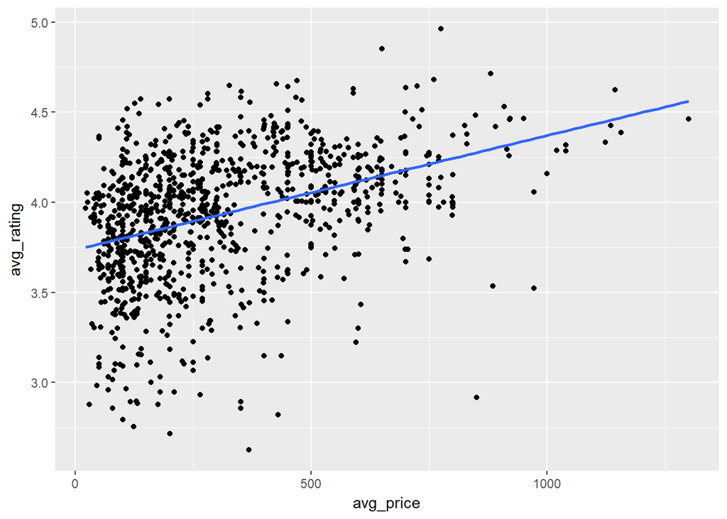

```r
#Scatterplot - Rating vs. Price
ggplot(amz_products, aes(y=avg_rating, x=avg_price))+
geom_point()+
stat_smooth(method="lm", se=F)
```

#### The correlation test that came out significant confirms that there is a moderate postive association between rating and price.

```r
#Correlation - Price with Rating
cor.test (amz_products$avg_price, amz_products$avg_rating, use="pairwise.complete.obs")
```

```
##
##  Pearson's product-moment correlation
##
## data:  amz_products$avg_price and amz_products$avg_rating
## t = 13.378, df = 1026, p-value < 2.2e-16
## alternative hypothesis: true correlation is not equal to 0
## 95 percent confidence interval:
##  0.3320861 0.4362655
## sample estimates:
##       cor
## 0.3854033
```

#### The next step is to estimate if there are any relationships between Brand Name and Rating. By looking again at the summary by brand, we realize that the brands are not equally represented by the number of products. There are some brands that contain just 1 product. So it makes sense to group less popular brands into one category “Other”.

```r
#Group by brand.name.clean
amz_products%>%
count(brand.name.clean)%>%
as.data.frame()
```

```
##    brand.name.clean   n
## 1           Alcatel   2
## 2             Apple 268
## 3              Asus  10
## 4        Blackberry  42
## 5               BLU  99
## 6             Casio   3
## 7        CAT PHONES   1
## 8           ECOOPRO   2
## 9              FIGO   2
## 10           Google  25
## 11        GreatCall   4
## 12          Hipipoo   1
## 13              HTC  34
## 14           Huawei  21
```

[output cut: 16 more lines]

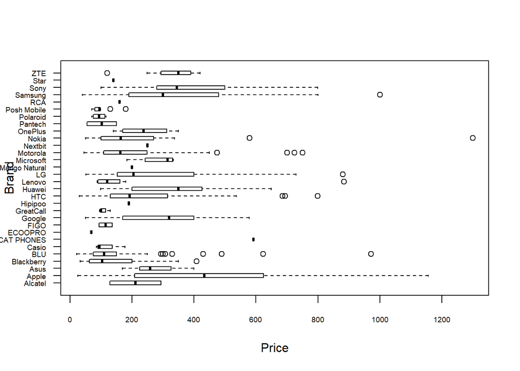

```r
#Distribution of price for each brand
boxplot(avg_price~brand.name.clean, data=amz_products, boxwex = 0.5,horizontal = TRUE, las = 1, cex.axis = 0.6,xlab="Price", ylab="Brand")
```

#### We check the distribution of prices first to make sure that the brands combined into “Other” have more or less similar price points.

```r
#Group brand names
amz_products<-amz_products %>%
mutate(brand.name.group=case_when(brand.name.clean %in% (c("Alcatel","Asus","Casio","CAT PHONES", "ECOOPRO", "FIGO","GreatCall", "Hipipoo", "Lenovo","Mango Natural", "Nextbit", "OnePlus","Pantech", "Polaroid", "Posh Mobile", "RCA", "Star", "ZTE", "HTC", "Huawei", "Motorola", "Sony")) ~ "Other",
brand.name.clean=="Microsoft" ~ "Nokia",
TRUE ~ as.character(brand.name.clean)))

#Group by brand.name.group
amz_products%>%
count(brand.name.group)%>%
as.data.frame()
```

```
##   brand.name.group   n
## 1            Apple 268
## 2       Blackberry  42
## 3              BLU  99
## 4           Google  25
## 5               LG  66
## 6            Nokia  61
## 7            Other 225
## 8          Samsung 242
```

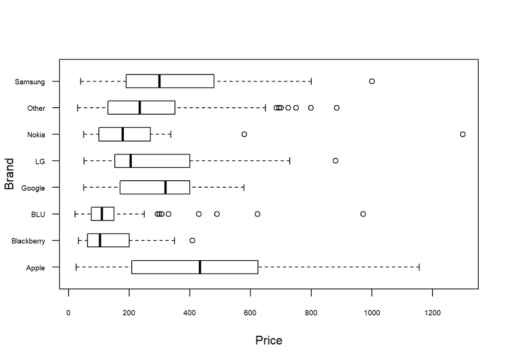

```r
#Distribution of price for each brand
boxplot(avg_price~brand.name.group, data=amz_products, boxwex = 0.5,horizontal = TRUE, las = 1, cex.axis = 0.6, xlab="Price", ylab="Brand")
```

#### Now we can build the distribution of ratings for each brand and see that there is some variablitly among brands.Some brands like Apple, Google, LG, and Samsung tend to have slightly higher ratings. It would be interesting to test if the observed differences between brands are significant and also if the relationship between price and rating identified above holds true for different brands.

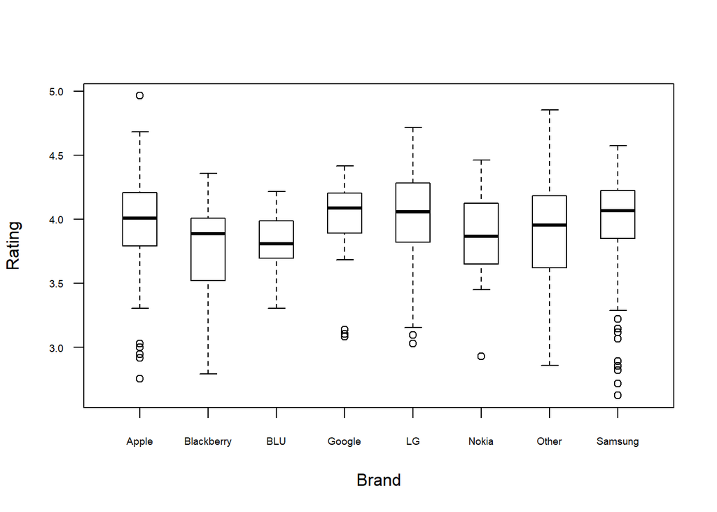

```r
#Distribution of rating for each brand
boxplot(avg_rating~brand.name.group, data=amz_products, boxwex = 0.5,horizontal = FALSE, las = 1, cex.axis = 0.6, xlab="Brand", ylab="Rating")
```

#### We build a view where we can represent ratings vs. prices for each brand separately. In addition, the size of the circles means sales (how many times each product was purchased). At the first sight, it seems that the linear relationships discovered for the whole dataset hold true for each brand separately, except Blackberry and BLU. However, if we look closer at the size of the circles, for example, Nokia, we notice that the influential leverage points that affect the slope of the line, are small. It means that those points contain less sales. It doesn’t mean that the smallest point corresponds to 1 sale, becasue the minimum is 13 sales (we look at the summary of counts to check this). But this is still rather small compared to the average sales for each product (almost 300 times).Even though, outliers (product with prices above $1300) were previously excluded from the analysis, it looks like there are still some products in the range of $500-1000 that could be outliers affecting the relationships between rating and price for specific brands such as Nokia, Blackberry, BLU, Samsung, LG.

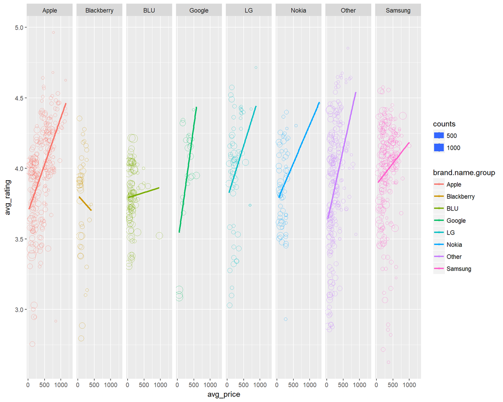

```r
#Rating vs. Price by Brand
ggplot(amz_products, aes(y=avg_rating, x=avg_price,col=brand.name.group, size=counts))+
geom_point(shape=1, alpha=0.6)+
geom_smooth(method="lm", se=FALSE)+
facet_grid(.~brand.name.group)
```

```r
#Summary of product sales
summary(amz_products$counts)
```

```
##    Min. 1st Qu.  Median    Mean 3rd Qu.    Max.
##    13.0   102.0   215.0   294.2   408.5  1451.0
```

#### Next, with an aim to understand what other variables might have some relationships with rating, it makes sense to investigate product features that were extracted previously as potential influencers of product rating. We first look at Feature.Storage as one of the features that contained the smallest amount of missing values. Before building the distribution of ratings for each storage level, we first need to clean this field.

```r
#Substitute missing values with NA
amz_products<-amz_products %>%
mutate(Feature.Storage=replace(Feature.Storage, Feature.Storage=="", NA))

#clean Feature.Storage
amz_products<-amz_products %>%
mutate(Feature.Storage=case_when(Feature.Storage=="1 GB" ~ "1GB",
                                Feature.Storage=="2 GB" ~ "2GB",
                                Feature.Storage=="128 GB" ~ "128GB",
                                Feature.Storage=="256 GB" ~ "256GB",
                                Feature.Storage %in% (c("16 GB","16gb")) ~ "16GB",
                                Feature.Storage %in% (c("32 gb","32 GB", "32gb", "32Gb")) ~ "32GB",
                                Feature.Storage %in% (c("4 GB","4gb")) ~ "4GB",
                                Feature.Storage %in% (c("64 GB","64gb")) ~ "64GB",
                                Feature.Storage %in% (c("8 GB","8gb","8Gb")) ~ "8GB",
                                TRUE ~ as.character(Feature.Storage)))

#sort Feature.Storage
amz_products<-amz_products %>%
mutate(Feature.Storage.Sort=case_when(Feature.Storage=="1GB" ~ "A1GB",
                                Feature.Storage=="2GB" ~ "B2GB",
                                Feature.Storage=="3GB" ~ "C3GB",
                                Feature.Storage=="4GB" ~ "D4GB",
                                Feature.Storage=="8GB" ~ "E8GB",
                                Feature.Storage=="16GB" ~ "F16GB",
                                Feature.Storage=="32GB" ~ "G32GB",
                                Feature.Storage=="64GB" ~ "H64GB",
                                Feature.Storage=="128GB" ~ "I128GB",
                                Feature.Storage=="256GB" ~ "J256GB",
                                TRUE ~ as.character(Feature.Storage)))
```

#### There are just a few products with the storage 1Gb,2GB,and 3GB that might be potentially grouped together. Excluding 4GB phones, it looks like that there is some linear relationship between storage and rating. As storage increases, so does the rating.

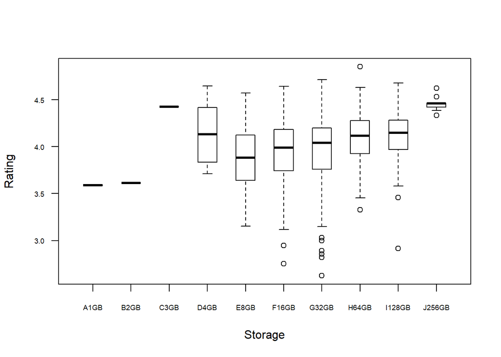

```r
#Distribution of rating for each level of storage
boxplot(avg_rating~Feature.Storage.Sort, data=amz_products, boxwex = 0.5,horizontal = FALSE, las = 1, cex.axis = 0.6, xlab="Storage", ylab="Rating")
```

#### After that we clean Feature.Conn, i.e. Technology by combining the corresponding levels into groups: 2G, 3G, and 4G.

```r
#Substitute missing values with NA
amz_products<-amz_products %>%
mutate(Feature.Conn=replace(Feature.Conn, Feature.Conn=="", NA))

#clean Feature.Conn
amz_products<-amz_products %>%
mutate(Feature.Conn=case_when(
                                Feature.Conn %in% (c("2G","Dualband GSM","Gsm","GSM","GSM      GSM","GSM    QuadBand","GSM   GSM","GSM Quadband","GSM QuadBand","QuadBand","QuadBand GSM")) ~ "2G",
                                Feature.Conn %in% (c("3g","3G","3G    CDMA","3G    GSM","3G   GSM","DualBand 3G","GSM      3G","GSM    3G","GSM 3G","QUADBAND 3G","QuadBand 3G GSM","3G   2G","CDMA","CDMA GSM","GSM    CDMA","GSM CDMA")) ~ "3G",
                                Feature.Conn %in% (c("4g","4G","4G        LTE WCDMA GSM","4G     GSM","4G    GSM","4G   4G LTE","4G   LTE","4G HSPA+","4G HSPA+    GSM","4g Lte","4g LTE","4G LTE","4G LTE      GSM","4G LTE     GSM","4G LTE    GSM","4G LTE   GSM"," 4G LTE GSM","CDMA 4G LTE","GSM        4G LTE","GSM      4G","GSM      4G LTE","GSM     4G","GSM     4G LTE","Gsm    4g LTE","GSM    CDMA 4G LTE","GSM   4G LTE","GSM   LTE","GSM 4G LTE","GSM LTE","LTE","LTE      GSM","LTE    4G LTE HSPA+", "LTE    GSM","LTE   GSM","LTE 4g","LTE 4G   GSM","4G LTE GSM","2G   4G LTE","4G LTE    2G","3G   4G LTE","LTE      3G","LTE LTE   3G","4G 3G 2G 2G GSM ","LTE 4G 3G 2G","LTE 4G 3G 2G GSM","LTE 4G 3G 2G GSM    2G 3G   4G LTE","4G 3G 2G 2G GSM")) ~ "4G",
                                TRUE ~ as.character(Feature.Conn)))
#clean Feature.Conn
amz_products<-amz_products %>%
mutate(Feature.Conn=case_when(!is.na(Feature.Conn) ~ Feature.Conn,
                               grepl('iPhone [56789]', Features.Txt,ignore.case=TRUE) ~ '4G',
                               grepl('iPhone SE', Features.Txt,ignore.case=TRUE) ~ '4G',
                               grepl('Samsung Galaxy S[678]', Features.Txt,ignore.case=TRUE) ~ '4G',
                               grepl('Sony Xperia X', Features.Txt,ignore.case=TRUE) ~ '4G',
                               grepl('iPhone [43]', Features.Txt,ignore.case=TRUE) ~ '3G',
                               TRUE ~ as.character(Feature.Conn)))
```

#### The ratings vary for each level of technology. It looks like phones that are 4G enabled tend to have higher ratings, which makes sense. Interesting that the phones with older technology, such as 2G have slightly higher ratings than phones with 3G.

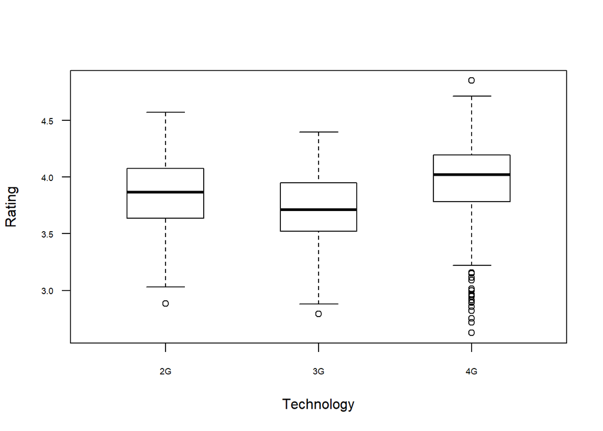

```r
#Distribution of rating for each level of storage
boxplot(avg_rating~Feature.Conn, data=amz_products, boxwex = 0.5,horizontal = FALSE, las = 1, cex.axis = 0.6, xlab="Technology", ylab="Rating")
```

#### Other product features that could potentially influence product rating and had one of the smallest amount of missing values, were Feature.Lock and Feature.Type. However, it turns out that these fields are not appropriate for further analysis. Almost all phones in this dataset are unlocked which makes this field useless. As for phone type, by exploring and filtering the dataset with the help of View, we noticed that for example, iPhones are not smartphones, but phones. So this field also does not represent any additional value for further analysis.

```r
#group by Feature.Lock
amz_products%>%
count(Feature.Lock)%>%
as.data.frame()
```

```
##   Feature.Lock   n
## 1              209
## 2       Locked   1
## 3     unlocked   8
## 4     Unlocked 803
## 5     UNLOCKED   7
```

```r
#group by Feature.Type
amz_products%>%
count(Feature.Type)%>%
as.data.frame()
```

```
##    Feature.Type   n
## 1               281
## 2     Cellphone 167
## 3     CellPhone  10
## 4          Flip   1
## 5         phone   2
## 6         Phone 189
## 7         PHONE   2
## 8    smartphone   8
## 9    Smartphone 359
## 10   SmartPhone   1
## 11   SMARTPHONE   7
## 12       Tablet   1
```

#### Next we clean other features: Os, Color, Sim, Geo, Warranty, Used, and Carrier.

```r
#clean Feature.Os
amz_products<-amz_products %>%
mutate(Feature.Os=replace(Feature.Os, Feature.Os=="", NA)) %>%
mutate(Feature.Os=case_when(!is.na(Feature.Os) ~ Feature.Os,
                               grepl('iPhone',  Features.Txt,ignore.case=TRUE) ~ 'iOs',
                               grepl('Apple',   Features.Txt,ignore.case=TRUE) ~ 'iOs',
                               grepl('BlackBerry',  Features.Txt,ignore.case=TRUE) ~ 'BlackBerry',
                               grepl('Microsoft',   Features.Txt,ignore.case=TRUE) ~ 'Windows',
                               grepl('Lumia',   Features.Txt,ignore.case=TRUE) ~ 'Windows',
                               grepl('nokia n9',    Features.Txt,ignore.case=TRUE) ~ 'meego',
                               grepl('nokia e[67]',Features.Txt,ignore.case=TRUE) ~ 'symbian', # also E71 E72
                               grepl('nokia',Features.Txt,ignore.case=TRUE) ~ 'feature',
                               grepl('(galaxy|droid)',Features.Txt,ignore.case=TRUE) ~ 'Androind',
                               grepl('sony xperia',Features.Txt,ignore.case=TRUE) ~ 'Androind',
                               grepl('samsung (note|captivate)',Features.Txt,ignore.case=TRUE) ~ 'Androind',
                               grepl('samsung (convoy|rugby|u380|evergreen|flight|knack|alias)',Features.Txt,ignore.case=TRUE) ~ 'feature',
                               grepl('alcatel onetouch',Features.Txt,ignore.case=TRUE) ~ 'Androind',
                               grepl('motorola razr v3',Features.Txt,ignore.case=TRUE) ~ 'feature',
                               grepl('motorola (tundra|v860)',Features.Txt,ignore.case=TRUE) ~ 'feature',
                               grepl('lg (a275|xeon|neon|octane|xenon|xpression)',Features.Txt,ignore.case=TRUE) ~ 'feature',
                               grepl('asus zenfone',Features.Txt,ignore.case=TRUE) ~ 'Androind',
                               grepl('nexus',Features.Txt,ignore.case=TRUE) ~ 'Androind',
                               grepl('moto [gzxe]',Features.Txt,ignore.case=TRUE) ~ 'Androind',
                               grepl('htc (status )?(one|desire|chacha|10)',Features.Txt,ignore.case=TRUE) ~ 'Androind',
                               grepl('htc 8x',Features.Txt,ignore.case=TRUE) ~ 'Windows',
                               grepl('zte axon',Features.Txt,ignore.case=TRUE) ~ 'Androind',
                               grepl('\\blg (electronics )?[vg]',Features.Txt,ignore.case=TRUE) ~ 'Androind',
                               grepl('LG Electronics LG-D855-G3',Features.Txt,ignore.case=TRUE) ~ 'Androind',
                               grepl('LG enV2 VX-9100',Features.Txt,ignore.case=TRUE) ~ 'feature',
                               grepl('LG KP500 Cookie',Features.Txt,ignore.case=TRUE)  ~ 'feature',
                               grepl('Pantech Burst P9070',Features.Txt,ignore.case=TRUE) ~ 'Androind',
                               grepl('Posh Memo S580',Features.Txt,ignore.case=TRUE) ~ 'Androind',
                               grepl('Posh Micro X S240',Features.Txt,ignore.case=TRUE) ~ 'Androind',
                               grepl('VIVO IV',Features.Txt,ignore.case=TRUE) ~ 'Androind',
                               grepl('\\blg optimus',Features.Txt,ignore.case=TRUE) ~ 'Androind',
                               grepl('\\bBLU\\b',Features.Txt,ignore.case=TRUE) ~ 'Androind',
                               grepl('(Huawei|OnePlus|ecoopro)',Features.Txt,ignore.case=TRUE) ~ 'Androind',
                               grepl('lenovo (a916|vibe)',Features.Txt,ignore.case=TRUE) ~ 'Androind',
                               grepl('honor 8',Features.Txt,ignore.case=TRUE) ~ 'Androind',
                               grepl('one x',Features.Txt,ignore.case=TRUE) ~ 'Androind',
                               grepl('pure mini',Features.Txt,ignore.case=TRUE) ~ 'Androind',
                               grepl('nextbit robin',Features.Txt,ignore.case=TRUE) ~ 'Androind',
                               grepl('Jitterbug',Features.Txt,ignore.case=TRUE) ~ 'feature',
                               grepl('Casio GzOne',Features.Txt,ignore.case=TRUE) ~ 'feature',
                               grepl('cat phone s60',Features.Txt,ignore.case=TRUE) ~ 'Android',
                               grepl('figo atrium',Features.Txt,ignore.case=TRUE) ~ 'Android',
                               TRUE ~ as.character(Feature.Os)))


#Clean Feature.Os
amz_products<-amz_products %>%
mutate(Feature.Os=case_when(Feature.Os %in% (c("ANDROID","Androind","KitKat","Lollipop")) ~ "Android",
                            Feature.Os %in% (c("meego","symbian")) ~ "Other",
                            TRUE ~ as.character(Feature.Os)))
#Substitute NA with "Other"
amz_products<-amz_products %>%
mutate(Feature.Os=replace(Feature.Os, is.na(Feature.Os), "Other"))

#group by Feature.Os
amz_products%>%
count(Feature.Os)%>%
as.data.frame()
```

```
##   Feature.Os   n
## 1    Android 620
## 2 BlackBerry  42
## 3    feature  48
## 4        iOs 268
## 5      Other   9
## 6    Windows  41
```

```r
#Clean Feature.Color
amz_products<-amz_products %>%
mutate(Feature.Color=replace(Feature.Color, Feature.Color=="", "Other")) %>%
mutate(Feature.Color=case_when(Feature.Color %in% (c("Amber Gold","Champagne Gold","Copper","COPPER","Copper Gold","Frosted Gold","GOLD","Gold    Gold","Gold    Gold Platinum","Gold   Gold","Gold Platinum","Golden","Metallic Gold","Platinum Gold","Sunrise Gold","TOPAZ GOLD")) ~ "Gold",
                            Feature.Color %in% (c("black","BLACK","Black    Black","Black Sapphire","Black Titanium","Carbon   Black","Carbon Black","CARBON BLACK","Charcoal Black","Metallic Black","Pearl    Black","Sapphire Black","Titan    Black","TITAN    BLACK","Titan Black")) ~ "Black",
                            Feature.Color %in% (c("Black   Grey","Black   White","Black Gold","Black Pink","Black Red","Brown Black","Gold    White","Gold   Grey","Gray   Red","Multicolor   BLACK","Multicolor   BLUE","Multicolor   GOLD","Multicolor   WHITE","Opal Blue   Blue White","Pink Gold","Rose   White","Silver   Gold","Silver   White","White   Red","White Blue","White Silver")) ~ "Multicolor",
                            Feature.Color %in% (c("BLUE","BLUE CORAL","Blue Topaz","Camo Blue","Carbon Blue","Dark Blue","Ocean Blue","Phthalo Blue","Sapphire Blue","Sky Blue","TITAN    BLUE"))~"Blue",
                            Feature.Color %in% (c("Camo Green","Emerald Green","Green Emerald","Titan    Green"))~"Green",
                            Feature.Color %in% (c("Camo White","Dazzling White","Moonlight White","Pearl White","Shimmery White","TITAN    WHITE","white","WHITE","White      White","White    White","White    WHITE","White Pearl"))~"White",
                            Feature.Color %in% (c("Carbon Gray","Chromium Silver","Dark Grey","Glacier","Glacier Silver","GLACIER SILVER","Gray","Gray      Gray","grey","Grey","GREY","Moonlight Silver","Platinum","PLATINUM","silver","SILVER","Silver   Dark Platinum","Silver Titanium","Titan","TITAN","Titanium","Titanium Gray","TITANIUM GREY","Titanium Silver"))~"Silver",
                            Feature.Color %in% (c("CORAL RED"))~"Red",
                            Feature.Color %in% (c("Lavender","Purple","PURPLE"))~"Purple",
                            Feature.Color %in% (c("Opal Pink","PINK"))~"Pink",
                            Feature.Color %in% (c("Orange   Orange"))~"Orange",
                            Feature.Color %in% (c("Titan    Yellow"))~"Yellow",
                            Feature.Color %in% (c("Rose","Rose Gold","ROSE GOLD"))~"Rose Gold",
                            Feature.Color %in% (c("Dark"))~"Other",
                            TRUE ~ as.character(Feature.Color)))

#group by Feature.Color
amz_products%>%
count(Feature.Color)%>%
as.data.frame()
```

```
##    Feature.Color   n
## 1          Black 274
## 2           Blue  53
## 3          Brown   3
## 4           Gold 127
## 5          Green  19
## 6     Multicolor  25
## 7         Orange  11
## 8          Other  49
## 9           Pink  18
## 10        Purple   3
## 11           Red  16
## 12     Rose Gold  23
## 13        Silver 181
## 14         White 214
## 15        Yellow  12
```

```r
#Clean Feature.Sim
amz_products<-amz_products %>%
mutate(Feature.Sim=replace(Feature.Sim, Feature.Sim=="", "Single")) %>%
mutate(Feature.Sim=case_when(Feature.Sim %in% (c("DualMicro SIM","Dualsim","DualSim","DualSIM")) ~ "Dual",
                                Feature.Sim %in% (c("Single Sim","Single SIM","SINGLE SIM")) ~ "Single",
                                TRUE ~ as.character(Feature.Sim)))
#group by Feature.Sim
amz_products%>%
count(Feature.Sim)%>%
as.data.frame()
```

```
##   Feature.Sim   n
## 1        Dual 102
## 2      Single 926
```

```r
#Clean Feature.Geo
amz_products<-amz_products %>%
mutate(Feature.Geo=replace(Feature.Geo, Feature.Geo=="", "US")) %>%
mutate(Feature.Geo=case_when(Feature.Geo %in% (c("EU","Global","International version","International Version","INTERNATIONAL VERSION")) ~ "International",
                                Feature.Geo %in% (c("US Version")) ~ "US",
                                TRUE ~ as.character(Feature.Geo)))
#group by Feature.Geo
amz_products%>%
count(Feature.Geo)%>%
as.data.frame()
```

```
##     Feature.Geo   n
## 1 International 174
## 2            US 854
```

```r
#Clean Feature.Warranty
amz_products<-amz_products %>%
mutate(Feature.Warranty=replace(Feature.Warranty, Feature.Warranty=="", "No")) %>%
mutate(Feature.Warranty=case_when(Feature.Warranty %in% (c("Nowarranty","NoWarranty","NoWARRANTY")) ~ "No",
                                Feature.Warranty %in% (c("warranty","Warranty")) ~ "Yes",
                                TRUE ~ as.character(Feature.Warranty)))

#group by Feature.Warranty
amz_products%>%
count(Feature.Warranty)%>%
as.data.frame()
```

```
##   Feature.Warranty   n
## 1               No 908
## 2              Yes 120
```

```r
#Clean Feature.Used
amz_products<-amz_products %>%
mutate(Feature.Used=replace(Feature.Used, Feature.Used=="", "Other"))

#group by Feature.Used
amz_products%>%
count(Feature.Used)%>%
as.data.frame()
```

```
##            Feature.Used   n
## 1 Certified Refurbished  82
## 2                 Other 946
```

```r
#Clean Feature.Carrier
amz_products<-amz_products %>%
mutate(Feature.Carrier=replace(Feature.Carrier, Feature.Carrier=="", "Any")) %>%
mutate(Feature.Carrier=case_when(Feature.Carrier=="At&t" ~ "AT&T",
                                Feature.Carrier=="T-MOBILE" ~ "T-Mobile",
                                Feature.Carrier=="VERIZON" ~ "Verizon",
                                Feature.Carrier %in% (c("BOOST","Virgin")) ~ "Other",
                                TRUE ~ as.character(Feature.Carrier)))

                                #group by Feature.Carrier
amz_products%>%
count(Feature.Carrier)%>%
as.data.frame()
```

```
##   Feature.Carrier   n
## 1             Any 855
## 2            AT&T  47
## 3           Other   2
## 4          Sprint  20
## 5        T-Mobile  28
## 6         Verizon  76
```

#### After that, we build rating distributions for each feature where we can see that there is some variabiality and the rating differences among the levels of each feature.

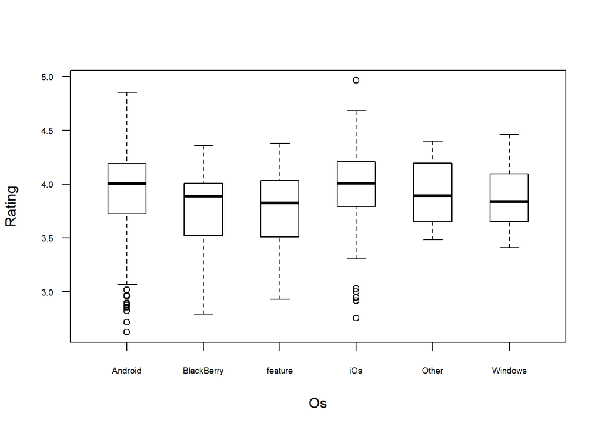

```r
#Distribution of rating for each level of Os
boxplot(avg_rating~Feature.Os, data=amz_products, boxwex = 0.5,horizontal = FALSE, las = 1, cex.axis = 0.6, xlab="Os", ylab="Rating")
```

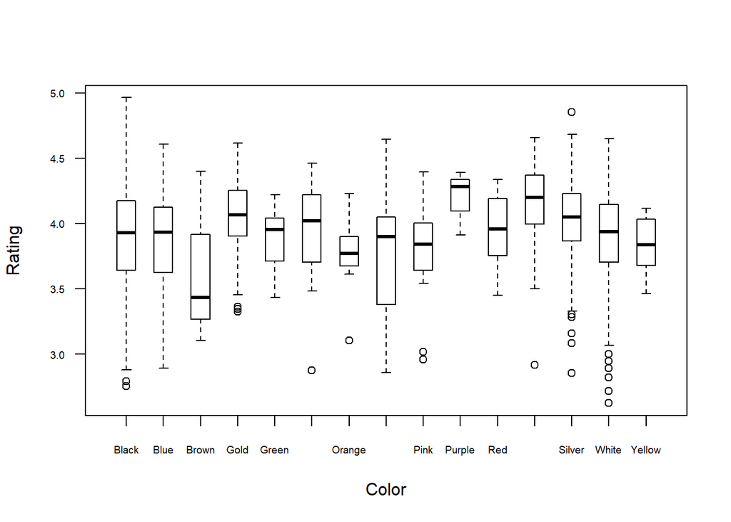

```r
#Distribution of rating for each level of Color
boxplot(avg_rating~Feature.Color, data=amz_products, boxwex = 0.5,horizontal = FALSE, las = 1, cex.axis = 0.6, xlab="Color", ylab="Rating")
```

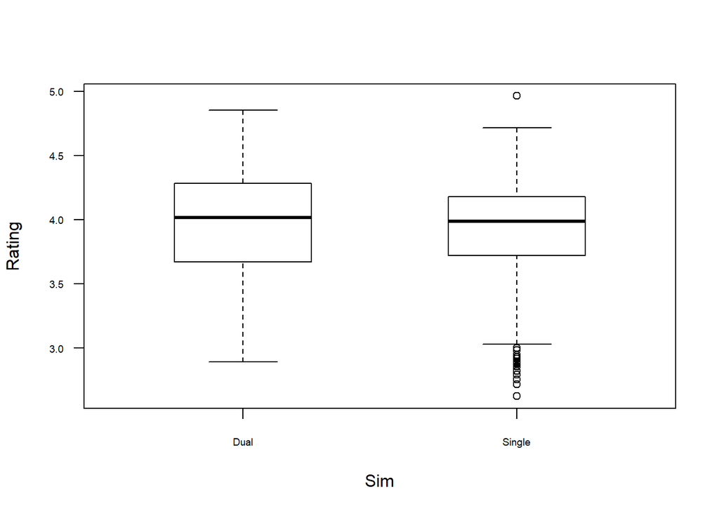

```r
#Distribution of rating for each level of Sim
boxplot(avg_rating~Feature.Sim, data=amz_products, boxwex = 0.5,horizontal = FALSE, las = 1, cex.axis = 0.6, xlab="Sim", ylab="Rating")
```

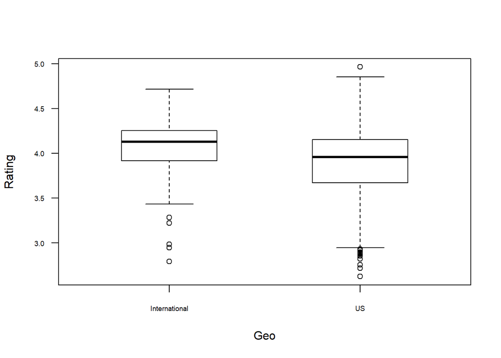

```r
#Distribution of rating for each level of Geo
boxplot(avg_rating~Feature.Geo, data=amz_products, boxwex = 0.5,horizontal = FALSE, las = 1, cex.axis = 0.6, xlab="Geo", ylab="Rating")
```

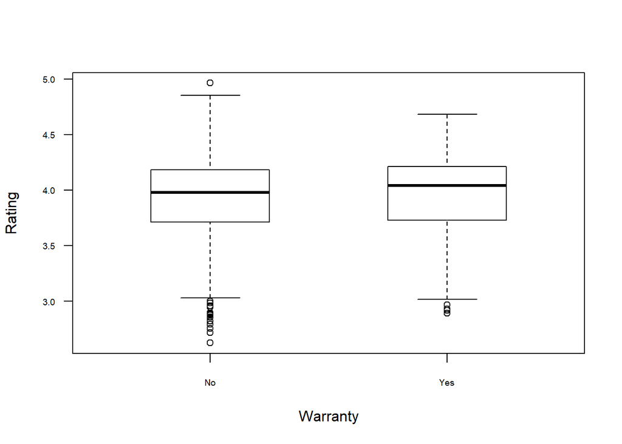

```r
#Distribution of rating for each level of Warranty
boxplot(avg_rating~Feature.Warranty, data=amz_products, boxwex = 0.5,horizontal = FALSE, las = 1, cex.axis = 0.6, xlab="Warranty", ylab="Rating")
```

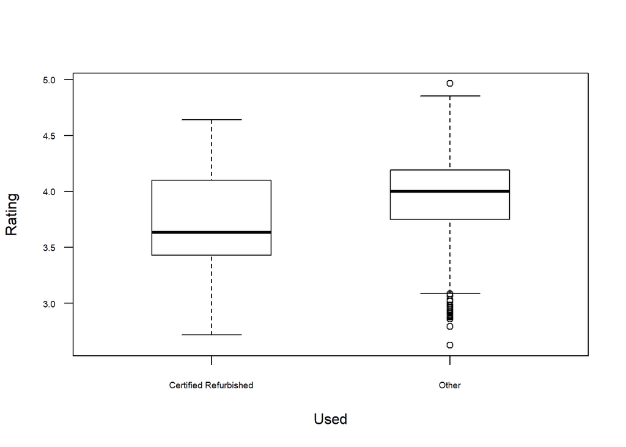

```r
#Distribution of rating for each level of Used
boxplot(avg_rating~Feature.Used, data=amz_products, boxwex = 0.5,horizontal = FALSE, las = 1, cex.axis = 0.6, xlab="Used", ylab="Rating")
```

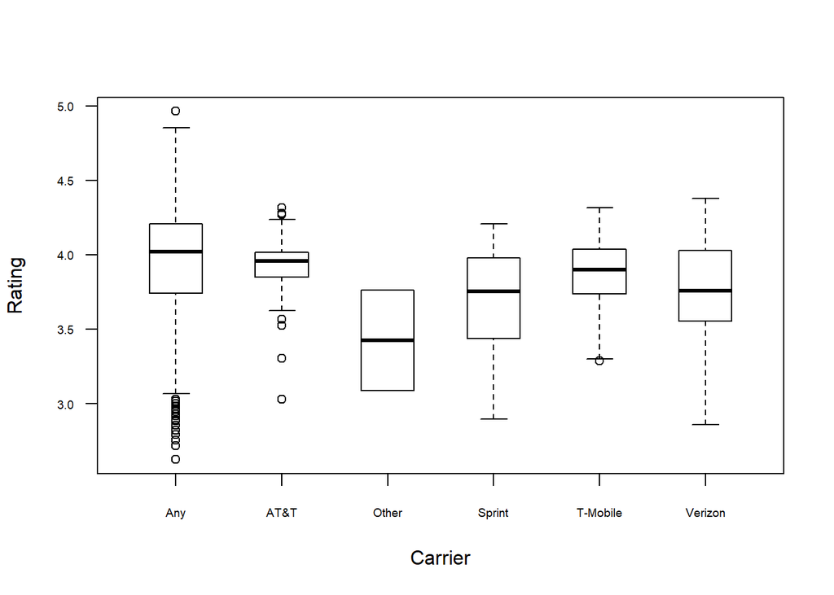

```r
#Distribution of rating for each level of Carrier
boxplot(avg_rating~Feature.Carrier, data=amz_products, boxwex = 0.5,horizontal = FALSE, las = 1, cex.axis = 0.6, xlab="Carrier", ylab="Rating")
```

# Cluster Analysis

#### First, we create a table with the fields for clustering: 7 product features, brand name, and price.

```r
library(cluster)    # clustering algorithms
library(factoextra) # clustering visualization
#Create table for clustering
amz_products_cls<-amz_products%>%
select(-brand.name.clean, -Features.Txt, -Feature.CPU, -Feature.Battery, -Feature.Ram, -Feature.Rugged, -Feature.Lock, -Feature.Type, -Feature.Mhz,-Feature.Storage.Sort, -Feature.Screen)
```

#### Next step is to recode categorical varibales (features and brand) into numeric.

```r
#Recode fields into numeric
#Color
amz_products_cls<-amz_products_cls %>%
mutate(Feature.Color.Recode=case_when(Feature.Color=="Black" ~ "1",
                                Feature.Color=="Gold" ~ "2",
                                Feature.Color=="Silver" ~ "3",
                                Feature.Color=="White" ~ "4",
                                Feature.Color=="Other" ~ "5"))

amz_products_cls$Feature.Color.Recode=as.numeric(amz_products_cls$Feature.Color.Recode)
summary(amz_products_cls$Feature.Color.Recode)
```

```
##    Min. 1st Qu.  Median    Mean 3rd Qu.    Max.
##   1.000   1.000   3.000   3.003   4.000   5.000
```

```r
#Warranty
amz_products_cls<-amz_products_cls %>%
mutate(Feature.Warranty.Recode=ifelse(Feature.Warranty=="Yes",1,0))

amz_products_cls$Feature.Warranty.Recode=as.numeric(amz_products_cls$Feature.Warranty.Recode)
summary(amz_products_cls$Feature.Warranty.Recode)
```

```
##    Min. 1st Qu.  Median    Mean 3rd Qu.    Max.
##  0.0000  0.0000  0.0000  0.1167  0.0000  1.0000
```

```r
#Sim
amz_products_cls<-amz_products_cls %>%
mutate(Feature.Sim.Recode=ifelse(Feature.Sim=="Single",1,2))

amz_products_cls$Feature.Sim.Recode=as.numeric(amz_products_cls$Feature.Sim.Recode)
summary(amz_products_cls$Feature.Sim.Recode)
```

```
##    Min. 1st Qu.  Median    Mean 3rd Qu.    Max.
##   1.000   1.000   1.000   1.099   1.000   2.000
```

```r
#Carrier
amz_products_cls<-amz_products_cls %>%
mutate(Feature.Carrier.Recode=case_when(Feature.Carrier=="AT&T" ~ "1",
                                Feature.Carrier=="Verizon" ~ "2",
                                Feature.Carrier=="T-Mobile" ~ "3",
                                Feature.Carrier=="Sprint" ~ "4",
                                Feature.Carrier=="Other" ~ "5",
                                Feature.Carrier=="Any" ~ "6"))

amz_products_cls$Feature.Carrier.Recode=as.numeric(amz_products_cls$Feature.Carrier.Recode)
summary(amz_products_cls$Feature.Carrier.Recode)
```

```
##    Min. 1st Qu.  Median    Mean 3rd Qu.    Max.
##   1.000   6.000   6.000   5.353   6.000   6.000
```

```r
#Used
amz_products_cls<-amz_products_cls %>%
mutate(Feature.Used.Recode=ifelse(Feature.Used=="Other",1,0))

amz_products_cls$Feature.Used.Recode=as.numeric(amz_products_cls$Feature.Used.Recode)
summary(amz_products_cls$Feature.Used.Recode)
```

```
##    Min. 1st Qu.  Median    Mean 3rd Qu.    Max.
##  0.0000  1.0000  1.0000  0.9202  1.0000  1.0000
```

```r
#Geo
amz_products_cls<-amz_products_cls %>%
mutate(Feature.Geo.Recode=ifelse(Feature.Geo=="US",1,0))

amz_products_cls$Feature.Geo.Recode=as.numeric(amz_products_cls$Feature.Geo.Recode)
summary(amz_products_cls$Feature.Geo.Recode)
```

```
##    Min. 1st Qu.  Median    Mean 3rd Qu.    Max.
##  0.0000  1.0000  1.0000  0.8307  1.0000  1.0000
```

```r
#Os
amz_products_cls<-amz_products_cls %>%
mutate(Feature.Os.Recode=case_when(Feature.Os=="Android" ~ "1",
                                Feature.Os=="iOs" ~ "2",
                                Feature.Os=="Windows" ~ "3",
                                Feature.Os=="BlackBerry" ~ "4",
                                Feature.Os=="Other" ~ "5",
                                Feature.Os=="feature" ~ "6"))

amz_products_cls$Feature.Os.Recode=as.numeric(amz_products_cls$Feature.Os.Recode)
summary(amz_products_cls$Feature.Os.Recode)
```

```
##    Min. 1st Qu.  Median    Mean 3rd Qu.    Max.
##   1.000   1.000   1.000   1.732   2.000   6.000
```

```r
#Brand
amz_products_cls<-amz_products_cls %>%
mutate(Brand.Recode=case_when(brand.name.group=="Samsung" ~ "1",
                                brand.name.group=="Apple" ~ "2",
                                brand.name.group=="LG" ~ "3",
                                brand.name.group=="Blackberry" ~ "4",
                                brand.name.group=="Nokia" ~ "5",
                                brand.name.group=="BLU" ~ "6",
                                brand.name.group=="Google" ~ "7",
                                brand.name.group=="Other" ~ "8"))

amz_products_cls$Brand.Recode=as.numeric(amz_products_cls$Brand.Recode)
summary(amz_products_cls$Brand.Recode)
```

```
##    Min. 1st Qu.  Median    Mean 3rd Qu.    Max.
##   1.000   2.000   3.000   3.909   6.000   8.000
```

#### Due to all variables have different scale, we standardize the variables before running the analysis.

```r
#Scale
amz_products_cls[,c("Feature.Color.Scale","Feature.Warranty.Scale","Feature.Sim.Scale","Feature.Carrier.Scale","Feature.Used.Scale","Feature.Geo.Scale","Feature.Os.Scale","Brand.Scale","Price.Scale")] <-scale (amz_products_cls[,c("Feature.Color.Recode","Feature.Warranty.Recode","Feature.Sim.Recode","Feature.Carrier.Recode","Feature.Used.Recode","Feature.Geo.Recode","Feature.Os.Recode","Brand.Recode","avg_price")])
```

#### Then, we calculate distance beween observations (products) by using Eucledian distance measure.

```r
#Calcualte distance - dissimilarity matrix
d.ecl<-dist(amz_products_cls[,c("Feature.Color.Scale","Feature.Warranty.Scale","Feature.Sim.Scale","Feature.Carrier.Scale","Feature.Used.Scale","Feature.Geo.Scale","Feature.Os.Scale","Brand.Scale","Price.Scale")], method="euclidean")
```

#### If we look at the matrix of distances between first 5 ovbservations, we see that for example, product 1 and 2 are far apart compared to 1 and 3.

```r
as.matrix(d.ecl)[1:5,1:5]
```

```
##          1        2         3         4        5
## 1 0.000000 7.035974 4.2024708 4.2738695 5.995671
## 2 7.035974 0.000000 5.9401074 5.9111363 5.269499
## 3 4.202471 5.940107 0.0000000 0.7508684 5.512881
## 4 4.273869 5.911136 0.7508684 0.0000000 5.468395
## 5 5.995671 5.269499 5.5128807 5.4683954 0.000000
```

#### After that, we use this dissimilarity matrix to run hierarchical cluster analysis using method Ward and plotting the output.

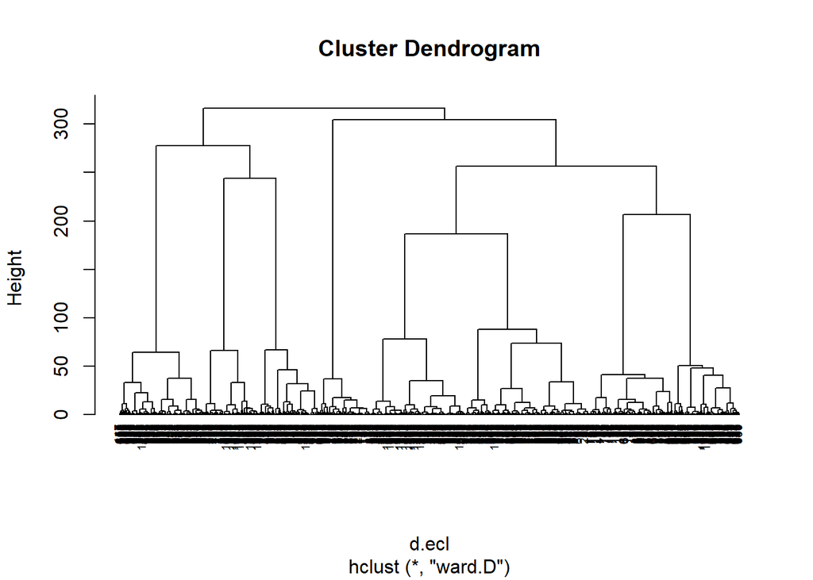

```r
#Run hierarchical clustering
set.seed(1234)
cls<-hclust(d.ecl,method="ward.D")
plot(cls, cex=0.6, hang=-1)
```

#### At first glance, we see from the dendrogram that there might be 8 distinct clusters. The biggest jump in height is when moving from 8 to 6 clusters, which means that at this stage the distinct clusters 5 and 6 are merged together, as well as even more distinct 7 and 8 clusters are merged into one. Let’s take a look at individual products from these clusters.

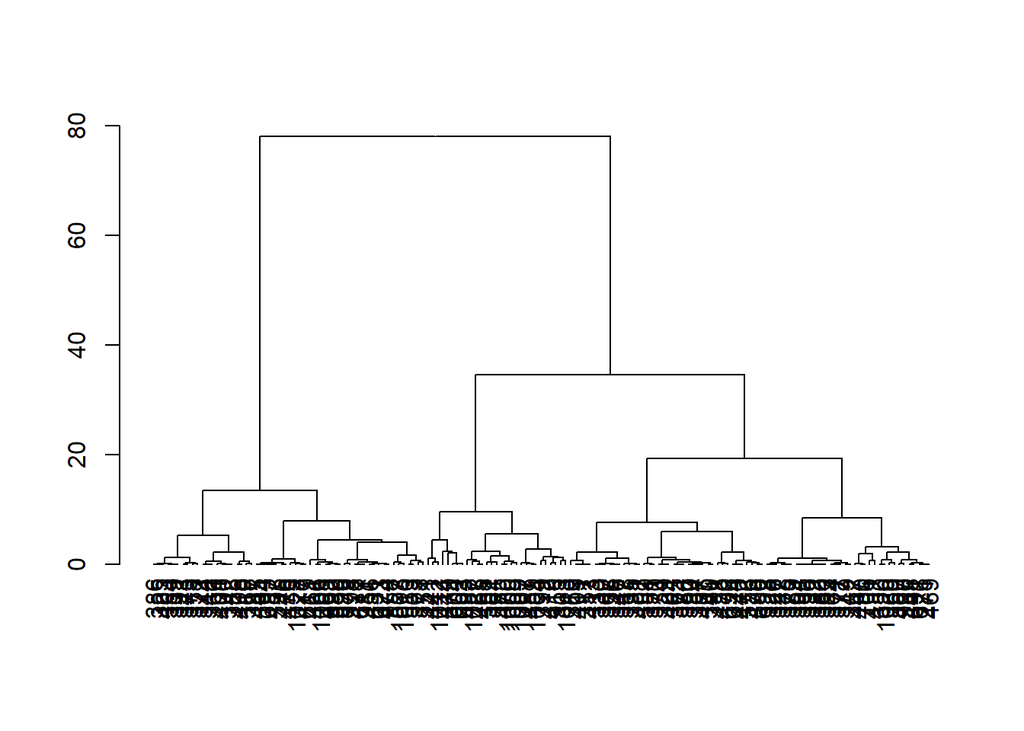

```r
#Check specific observations - cut at a certain height and select a branch
plot(cut(as.dendrogram(cls),h=90)$lower[[5]])
```

#### If we cut the tree at height 90 and select the 5th branch, we see that there are 4 sub-branches at height around 20. We check 3 products from the first sub-branch on the left and see that these are almost identical products that differ slightly by price. It makes total sense why these 3 products belong to the same cluster.

```r
#Check individual observations
View(amz_products_cls[c(386,325,403),])
```

#### Now when we look at the these three products from the first sub-branch on the left and other 2 products from the last sub-branch (on the right) we see that the products from these sub-branches are different on: price, color, and brand. But because they had everything else in common, they are the members of the same cluster, 5. These two sub-branches join together among the last with the biggest height, 80.

```r
#Check individual observations
View(amz_products_cls[c(386,325,403,469,271),])
```

#### If we look at some individual products from cluster 6, we notice that the first 2 observations from the first left sub-branch in cluster 6 has products with much higher price level, different color, technology, brand, and OS.

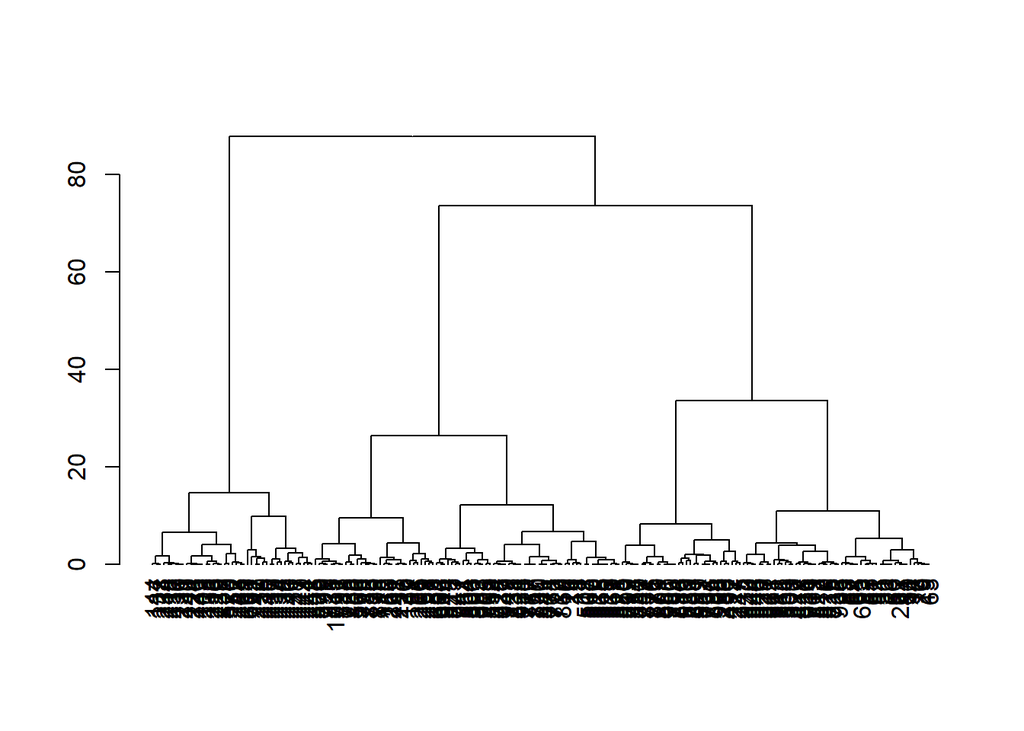

```r
plot(cut(as.dendrogram(cls),h=90)$lower[[6]])
```

```r
View(amz_products_cls[c(386,325,403,144,137),])
```

#### Since products from cluster 5 and cluster 6 differ on almost half of the variables, these clusters are joined together into one when the height is around 200. It’s twice higher jump. So the 8 cluster solution seems more reasonble compared to the 6 cluster solution that joins clusters that are far apart.

```r
#Check goodness-of-fit
cor(cophenetic(cls),d.ecl)
```

```
## [1] 0.6484022
```

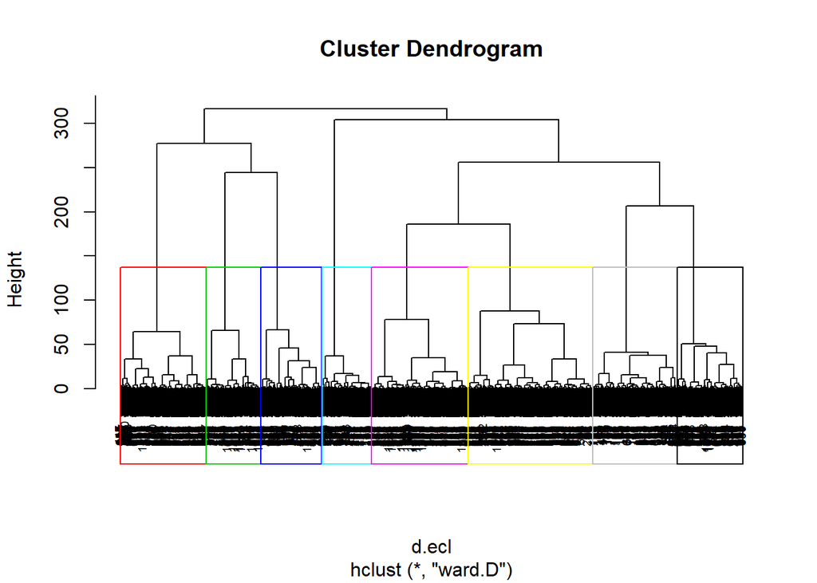

```r
#Cut tree into k groups
sub_grp<-cutree(cls,k=8)
#Add rectangle to each cluster
plot(cls, cex=0.6)
rect.hclust(cls, k=8, border=2:9)
```

#### If we look at how many products belong to each cluster, we see that it’s a pretty balanced solution with cluster 5 being slighlty overpopulated.

```r
#Calculate number of members in each cluster
table(sub_grp)
```

```
## sub_grp
##   1   2   3   4   5   6   7   8
## 109 101  90 139 206  82 142 159
```

#### We assign the cluster membership to each observation.

```r
#Add cluster number to each observations
amz_products_cls<-amz_products_cls %>%
mutate(cluster_ecl=sub_grp)
```

#### When we look at the cluster plot, we see that there is some overlap between some clusters but generally there are clusters that are far apart and do not overlap with each other.

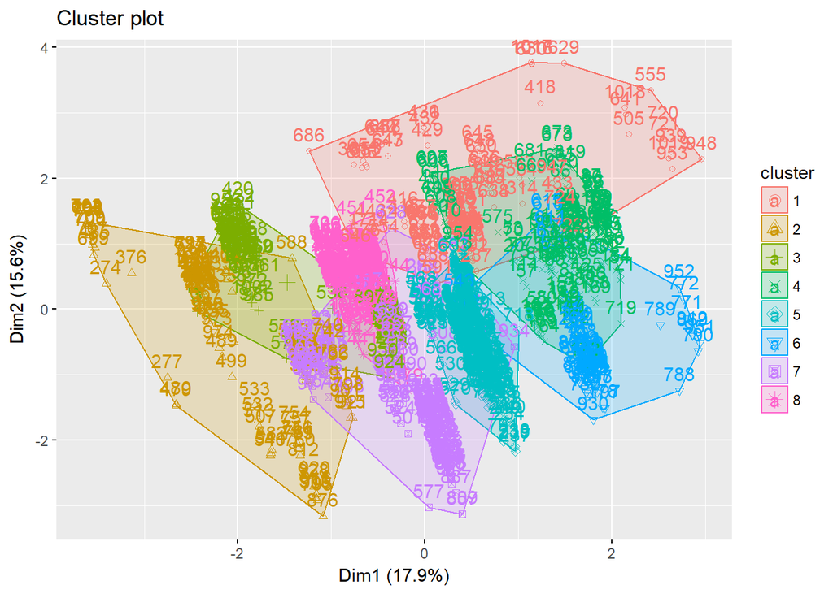

```r
#Cluster plot
fviz_cluster(list(data = amz_products_cls[,c("Feature.Color.Scale","Feature.Warranty.Scale","Feature.Sim.Scale","Feature.Carrier.Scale","Feature.Used.Scale","Feature.Geo.Scale","Feature.Os.Scale","Brand.Scale","Price.Scale")], cluster = sub_grp))
```

#### Next we examine the proportion of products in each cluster having specific feature and compare is those proportions are significantly different among clusters. Chi-square test confirmed that clusters differ on each feature.

```r
#Test proportions - cross-tabs
library(gmodels)
CT_Color<-CrossTable(as.factor(amz_products_cls$Feature.Color),as.factor(amz_products_cls$cluster_ecl), format=c("SPSS"), prop.r=FALSE, prop.c=TRUE, prop.t=FALSE, chisq=TRUE)
```

```
##
##    Cell Contents
## |-------------------------|
## |                   Count |
## | Chi-square contribution |
## |          Column Percent |
## |-------------------------|
##
## Total Observations in Table:  1028
##
##                                           | as.factor(amz_products_cls$cluster_ecl)
## as.factor(amz_products_cls$Feature.Color) |        1  |        2  |        3  |        4  |        5  |        6  |        7  |        8  | Row Total |
## ------------------------------------------|-----------|-----------|-----------|-----------|-----------|-----------|-----------|-----------|-----------|
##                                     Black |       46  |       22  |       23  |       27  |       56  |       15  |       47  |       38  |      274  |
##                                           |    9.886  |    0.899  |    0.041  |    2.725  |    0.022  |    2.151  |    2.213  |    0.453  |           |
##                                           |   42.202% |   21.782% |   25.556% |   19.424% |   27.184% |   18.293% |   33.099% |   23.899% |           |
## ------------------------------------------|-----------|-----------|-----------|-----------|-----------|-----------|-----------|-----------|-----------|
##                                      Gold |        0  |       16  |       13  |       18  |       32  |       12  |       16  |       20  |      127  |
##                                           |   13.466  |    0.994  |    0.318  |    0.040  |    1.686  |    0.345  |    0.136  |    0.006  |           |
##                                           |    0.000% |   15.842% |   14.444% |   12.950% |   15.534% |   14.634% |   11.268% |   12.579% |           |
## ------------------------------------------|-----------|-----------|-----------|-----------|-----------|-----------|-----------|-----------|-----------|
##                                     Other |       32  |       28  |       22  |       36  |       37  |       11  |       21  |       45  |      232  |
##                                           |    2.227  |    1.189  |    0.140  |    0.683  |    1.937  |    3.044  |    3.808  |    2.316  |           |
##                                           |   29.358% |   27.723% |   24.444% |   25.899% |   17.961% |   13.415% |   14.789% |   28.302% |           |
## ------------------------------------------|-----------|-----------|-----------|-----------|-----------|-----------|-----------|-----------|-----------|
##                                    Silver |       11  |       15  |       20  |       36  |       33  |       29  |       14  |       23  |      181  |
##                                           |    3.496  |    0.436  |    1.089  |    5.428  |    0.295  |   14.688  |    4.841  |    0.891  |           |
##                                           |   10.092% |   14.851% |   22.222% |   25.899% |   16.019% |   35.366% |    9.859% |   14.465% |           |
## ------------------------------------------|-----------|-----------|-----------|-----------|-----------|-----------|-----------|-----------|-----------|
##                                     White |       20  |       20  |       12  |       22  |       48  |       15  |       44  |       33  |      214  |
##                                           |    0.319  |    0.050  |    2.421  |    1.662  |    0.611  |    0.251  |    7.054  |    0.000  |           |
##                                           |   18.349% |   19.802% |   13.333% |   15.827% |   23.301% |   18.293% |   30.986% |   20.755% |           |
## ------------------------------------------|-----------|-----------|-----------|-----------|-----------|-----------|-----------|-----------|-----------|
##                              Column Total |      109  |      101  |       90  |      139  |      206  |       82  |      142  |      159  |     1028  |
##                                           |   10.603% |    9.825% |    8.755% |   13.521% |   20.039% |    7.977% |   13.813% |   15.467% |           |
## ------------------------------------------|-----------|-----------|-----------|-----------|-----------|-----------|-----------|-----------|-----------|
##
##
## Statistics for All Table Factors
##
##
## Pearson's Chi-squared test
## ------------------------------------------------------------
## Chi^2 =  94.25955     d.f. =  28     p =  4.22709e-09
##
##
##
##        Minimum expected frequency: 10.13035
```

```r
CT_Warranty<-CrossTable(as.factor(amz_products_cls$Feature.Warranty),as.factor(amz_products_cls$cluster_ecl), format=c("SPSS"), prop.r=FALSE, prop.c=TRUE, prop.t=FALSE, chisq=TRUE)
```

```
##
##    Cell Contents
## |-------------------------|
## |                   Count |
## | Chi-square contribution |
## |          Column Percent |
## |-------------------------|
##
## Total Observations in Table:  1028
##
##                                              | as.factor(amz_products_cls$cluster_ecl)
## as.factor(amz_products_cls$Feature.Warranty) |        1  |        2  |        3  |        4  |        5  |        6  |        7  |        8  | Row Total |
## ---------------------------------------------|-----------|-----------|-----------|-----------|-----------|-----------|-----------|-----------|-----------|
##                                           No |       92  |       88  |        0  |      139  |      206  |       82  |      142  |      159  |      908  |
##                                              |    0.190  |    0.016  |   79.494  |    2.144  |    3.178  |    1.265  |    2.191  |    2.453  |           |
##                                              |   84.404% |   87.129% |    0.000% |  100.000% |  100.000% |  100.000% |  100.000% |  100.000% |           |
## ---------------------------------------------|-----------|-----------|-----------|-----------|-----------|-----------|-----------|-----------|-----------|
##                                          Yes |       17  |       13  |       90  |        0  |        0  |        0  |        0  |        0  |      120  |
##                                              |    1.437  |    0.124  |  601.506  |   16.226  |   24.047  |    9.572  |   16.576  |   18.560  |           |
##                                              |   15.596% |   12.871% |  100.000% |    0.000% |    0.000% |    0.000% |    0.000% |    0.000% |           |
## ---------------------------------------------|-----------|-----------|-----------|-----------|-----------|-----------|-----------|-----------|-----------|
##                                 Column Total |      109  |      101  |       90  |      139  |      206  |       82  |      142  |      159  |     1028  |
##                                              |   10.603% |    9.825% |    8.755% |   13.521% |   20.039% |    7.977% |   13.813% |   15.467% |           |
## ---------------------------------------------|-----------|-----------|-----------|-----------|-----------|-----------|-----------|-----------|-----------|
##
##
## Statistics for All Table Factors
##
##
## Pearson's Chi-squared test
## ------------------------------------------------------------
## Chi^2 =  778.9792     d.f. =  7     p =  6.371886e-164
##
##
##
##        Minimum expected frequency: 9.571984
```

```r
CT_Sim<-CrossTable(as.factor(amz_products_cls$Feature.Sim),as.factor(amz_products_cls$cluster_ecl), format=c("SPSS"), prop.r=FALSE, prop.c=TRUE, prop.t=FALSE, chisq=TRUE)
```

```
##
##    Cell Contents
## |-------------------------|
## |                   Count |
## | Chi-square contribution |
## |          Column Percent |
## |-------------------------|
##
## Total Observations in Table:  1028
##
##                                         | as.factor(amz_products_cls$cluster_ecl)
## as.factor(amz_products_cls$Feature.Sim) |        1  |        2  |        3  |        4  |        5  |        6  |        7  |        8  | Row Total |
## ----------------------------------------|-----------|-----------|-----------|-----------|-----------|-----------|-----------|-----------|-----------|
##                                    Dual |        0  |      101  |        0  |        0  |        0  |        0  |        1  |        0  |      102  |
##                                         |   10.815  |  825.943  |    8.930  |   13.792  |   20.440  |    8.136  |   12.160  |   15.776  |           |
##                                         |    0.000% |  100.000% |    0.000% |    0.000% |    0.000% |    0.000% |    0.704% |    0.000% |           |
## ----------------------------------------|-----------|-----------|-----------|-----------|-----------|-----------|-----------|-----------|-----------|
##                                  Single |      109  |        0  |       90  |      139  |      206  |       82  |      141  |      159  |      926  |
##                                         |    1.191  |   90.979  |    0.984  |    1.519  |    2.251  |    0.896  |    1.339  |    1.738  |           |
##                                         |  100.000% |    0.000% |  100.000% |  100.000% |  100.000% |  100.000% |   99.296% |  100.000% |           |
## ----------------------------------------|-----------|-----------|-----------|-----------|-----------|-----------|-----------|-----------|-----------|
##                            Column Total |      109  |      101  |       90  |      139  |      206  |       82  |      142  |      159  |     1028  |
##                                         |   10.603% |    9.825% |    8.755% |   13.521% |   20.039% |    7.977% |   13.813% |   15.467% |           |
## ----------------------------------------|-----------|-----------|-----------|-----------|-----------|-----------|-----------|-----------|-----------|
##
##
## Statistics for All Table Factors
##
##
## Pearson's Chi-squared test
## ------------------------------------------------------------
## Chi^2 =  1016.89     d.f. =  7     p =  2.699398e-215
##
##
##
##        Minimum expected frequency: 8.136187
```

```r
CT_Carrier<-CrossTable(as.factor(amz_products_cls$Feature.Carrier),as.factor(amz_products_cls$cluster_ecl), format=c("SPSS"), prop.r=FALSE, prop.c=TRUE, prop.t=FALSE, chisq=TRUE)
```

```
##
##    Cell Contents
## |-------------------------|
## |                   Count |
## | Chi-square contribution |
## |          Column Percent |
## |-------------------------|
##
## Total Observations in Table:  1028
##
##                                             | as.factor(amz_products_cls$cluster_ecl)
## as.factor(amz_products_cls$Feature.Carrier) |        1  |        2  |        3  |        4  |        5  |        6  |        7  |        8  | Row Total |
## --------------------------------------------|-----------|-----------|-----------|-----------|-----------|-----------|-----------|-----------|-----------|
##                                         Any |       93  |      101  |       90  |        0  |      205  |       68  |      141  |      157  |      855  |
##                                             |    0.061  |    3.439  |    3.065  |  115.608  |    6.616  |    0.001  |    4.439  |    4.635  |           |
##                                             |   85.321% |  100.000% |  100.000% |    0.000% |   99.515% |   82.927% |   99.296% |   98.742% |           |
## --------------------------------------------|-----------|-----------|-----------|-----------|-----------|-----------|-----------|-----------|-----------|
##                                        AT&T |        4  |        0  |        0  |       43  |        0  |        0  |        0  |        0  |       47  |
##                                             |    0.194  |    4.618  |    4.115  |  211.304  |    9.418  |    3.749  |    6.492  |    7.269  |           |
##                                             |    3.670% |    0.000% |    0.000% |   30.935% |    0.000% |    0.000% |    0.000% |    0.000% |           |
## --------------------------------------------|-----------|-----------|-----------|-----------|-----------|-----------|-----------|-----------|-----------|
##                                       Other |        0  |        0  |        0  |        0  |        1  |        0  |        0  |        1  |        2  |
##                                             |    0.212  |    0.196  |    0.175  |    0.270  |    0.896  |    0.160  |    0.276  |    1.542  |           |
##                                             |    0.000% |    0.000% |    0.000% |    0.000% |    0.485% |    0.000% |    0.000% |    0.629% |           |
## --------------------------------------------|-----------|-----------|-----------|-----------|-----------|-----------|-----------|-----------|-----------|
##                                      Sprint |        1  |        0  |        0  |       17  |        0  |        0  |        1  |        1  |       20  |
##                                             |    0.592  |    1.965  |    1.751  |   75.572  |    4.008  |    1.595  |    1.125  |    1.417  |           |
##                                             |    0.917% |    0.000% |    0.000% |   12.230% |    0.000% |    0.000% |    0.704% |    0.629% |           |
## --------------------------------------------|-----------|-----------|-----------|-----------|-----------|-----------|-----------|-----------|-----------|
##                                    T-Mobile |        0  |        0  |        0  |       26  |        0  |        2  |        0  |        0  |       28  |
##                                             |    2.969  |    2.751  |    2.451  |  130.339  |    5.611  |    0.024  |    3.868  |    4.331  |           |
##                                             |    0.000% |    0.000% |    0.000% |   18.705% |    0.000% |    2.439% |    0.000% |    0.000% |           |
## --------------------------------------------|-----------|-----------|-----------|-----------|-----------|-----------|-----------|-----------|-----------|
##                                     Verizon |       11  |        0  |        0  |       53  |        0  |       12  |        0  |        0  |       76  |
##                                             |    1.074  |    7.467  |    6.654  |  177.625  |   15.230  |    5.816  |   10.498  |   11.755  |           |
##                                             |   10.092% |    0.000% |    0.000% |   38.129% |    0.000% |   14.634% |    0.000% |    0.000% |           |
## --------------------------------------------|-----------|-----------|-----------|-----------|-----------|-----------|-----------|-----------|-----------|
##                                Column Total |      109  |      101  |       90  |      139  |      206  |       82  |      142  |      159  |     1028  |
##                                             |   10.603% |    9.825% |    8.755% |   13.521% |   20.039% |    7.977% |   13.813% |   15.467% |           |
## --------------------------------------------|-----------|-----------|-----------|-----------|-----------|-----------|-----------|-----------|-----------|
##
##
## Statistics for All Table Factors
##
##
## Pearson's Chi-squared test
## ------------------------------------------------------------
## Chi^2 =  865.2362     d.f. =  35     p =  4.969051e-159
##
##
##
##        Minimum expected frequency: 0.1595331
## Cells with Expected Frequency < 5: 27 of 48 (56.25%)
```

```r
CT_Used<-CrossTable(as.factor(amz_products_cls$Feature.Used),as.factor(amz_products_cls$cluster_ecl), format=c("SPSS"), prop.r=FALSE, prop.c=TRUE, prop.t=FALSE, chisq=TRUE)
```

```
##
##    Cell Contents
## |-------------------------|
## |                   Count |
## | Chi-square contribution |
## |          Column Percent |
## |-------------------------|
##
## Total Observations in Table:  1028
##
##                                          | as.factor(amz_products_cls$cluster_ecl)
## as.factor(amz_products_cls$Feature.Used) |        1  |        2  |        3  |        4  |        5  |        6  |        7  |        8  | Row Total |
## -----------------------------------------|-----------|-----------|-----------|-----------|-----------|-----------|-----------|-----------|-----------|
##                    Certified Refurbished |        0  |        0  |        0  |        0  |        0  |       82  |        0  |        0  |       82  |
##                                          |    8.695  |    8.056  |    7.179  |   11.088  |   16.432  |  870.541  |   11.327  |   12.683  |           |
##                                          |    0.000% |    0.000% |    0.000% |    0.000% |    0.000% |  100.000% |    0.000% |    0.000% |           |
## -----------------------------------------|-----------|-----------|-----------|-----------|-----------|-----------|-----------|-----------|-----------|
##                                    Other |      109  |      101  |       90  |      139  |      206  |        0  |      142  |      159  |      946  |
##                                          |    0.754  |    0.698  |    0.622  |    0.961  |    1.424  |   75.459  |    0.982  |    1.099  |           |
##                                          |  100.000% |  100.000% |  100.000% |  100.000% |  100.000% |    0.000% |  100.000% |  100.000% |           |
## -----------------------------------------|-----------|-----------|-----------|-----------|-----------|-----------|-----------|-----------|-----------|
##                             Column Total |      109  |      101  |       90  |      139  |      206  |       82  |      142  |      159  |     1028  |
##                                          |   10.603% |    9.825% |    8.755% |   13.521% |   20.039% |    7.977% |   13.813% |   15.467% |           |
## -----------------------------------------|-----------|-----------|-----------|-----------|-----------|-----------|-----------|-----------|-----------|
##
##
## Statistics for All Table Factors
##
##
## Pearson's Chi-squared test
## ------------------------------------------------------------
## Chi^2 =  1028     d.f. =  7     p =  1.072954e-217
##
##
##
##        Minimum expected frequency: 6.540856
```

```r
CT_Geo<-CrossTable(as.factor(amz_products_cls$Feature.Geo),as.factor(amz_products_cls$cluster_ecl), format=c("SPSS"), prop.r=FALSE, prop.c=TRUE, prop.t=FALSE, chisq=TRUE)
```

```
##
##    Cell Contents
## |-------------------------|
## |                   Count |
## | Chi-square contribution |
## |          Column Percent |
## |-------------------------|
##
## Total Observations in Table:  1028
##
##                                         | as.factor(amz_products_cls$cluster_ecl)
## as.factor(amz_products_cls$Feature.Geo) |        1  |        2  |        3  |        4  |        5  |        6  |        7  |        8  | Row Total |
## ----------------------------------------|-----------|-----------|-----------|-----------|-----------|-----------|-----------|-----------|-----------|
##                           International |        3  |       25  |        4  |        0  |        0  |        0  |      142  |        0  |      174  |
##                                         |   12.937  |    3.655  |    8.284  |   23.527  |   34.868  |   13.879  |  578.978  |   26.912  |           |
##                                         |    2.752% |   24.752% |    4.444% |    0.000% |    0.000% |    0.000% |  100.000% |    0.000% |           |
## ----------------------------------------|-----------|-----------|-----------|-----------|-----------|-----------|-----------|-----------|-----------|
##                                      US |      106  |       76  |       86  |      139  |      206  |       82  |        0  |      159  |      854  |
##                                         |    2.636  |    0.745  |    1.688  |    4.794  |    7.104  |    2.828  |  117.965  |    5.483  |           |
##                                         |   97.248% |   75.248% |   95.556% |  100.000% |  100.000% |  100.000% |    0.000% |  100.000% |           |
## ----------------------------------------|-----------|-----------|-----------|-----------|-----------|-----------|-----------|-----------|-----------|
##                            Column Total |      109  |      101  |       90  |      139  |      206  |       82  |      142  |      159  |     1028  |
##                                         |   10.603% |    9.825% |    8.755% |   13.521% |   20.039% |    7.977% |   13.813% |   15.467% |           |
## ----------------------------------------|-----------|-----------|-----------|-----------|-----------|-----------|-----------|-----------|-----------|
##
##
## Statistics for All Table Factors
##
##
## Pearson's Chi-squared test
## ------------------------------------------------------------
## Chi^2 =  846.2828     d.f. =  7     p =  1.90211e-178
##
##
##
##        Minimum expected frequency: 13.87938
```

```r
CT_Os<-CrossTable(as.factor(amz_products_cls$Feature.Os),as.factor(amz_products_cls$cluster_ecl), format=c("SPSS"), prop.r=FALSE, prop.c=TRUE, prop.t=FALSE, chisq=TRUE)
```

```
##
##    Cell Contents
## |-------------------------|
## |                   Count |
## | Chi-square contribution |
## |          Column Percent |
## |-------------------------|
##
## Total Observations in Table:  1028
##
##                                        | as.factor(amz_products_cls$cluster_ecl)
## as.factor(amz_products_cls$Feature.Os) |        1  |        2  |        3  |        4  |        5  |        6  |        7  |        8  | Row Total |
## ---------------------------------------|-----------|-----------|-----------|-----------|-----------|-----------|-----------|-----------|-----------|
##                                Android |        0  |      100  |       64  |       31  |      116  |       29  |      122  |      158  |      620  |
##                                        |   65.739  |   25.079  |    1.741  |   33.296  |    0.547  |    8.461  |   15.435  |   40.221  |           |
##                                        |    0.000% |   99.010% |   71.111% |   22.302% |   56.311% |   35.366% |   85.915% |   99.371% |           |
## ---------------------------------------|-----------|-----------|-----------|-----------|-----------|-----------|-----------|-----------|-----------|
##                             BlackBerry |       35  |        0  |        0  |        1  |        0  |        0  |        6  |        0  |       42  |
##                                        |  209.530  |    4.126  |    3.677  |    3.855  |    8.416  |    3.350  |    0.007  |    6.496  |           |
##                                        |   32.110% |    0.000% |    0.000% |    0.719% |    0.000% |    0.000% |    4.225% |    0.000% |           |
## ---------------------------------------|-----------|-----------|-----------|-----------|-----------|-----------|-----------|-----------|-----------|
##                                feature |       45  |        0  |        0  |        0  |        0  |        0  |        3  |        0  |       48  |
##                                        |  312.968  |    4.716  |    4.202  |    6.490  |    9.619  |    3.829  |    1.988  |    7.424  |           |
##                                        |   41.284% |    0.000% |    0.000% |    0.000% |    0.000% |    0.000% |    2.113% |    0.000% |           |
## ---------------------------------------|-----------|-----------|-----------|-----------|-----------|-----------|-----------|-----------|-----------|
##                                    iOs |        0  |        0  |       26  |      100  |       88  |       53  |        1  |        0  |      268  |
##                                        |   28.416  |   26.331  |    0.274  |  112.196  |   21.901  |   46.778  |   35.046  |   41.451  |           |
##                                        |    0.000% |    0.000% |   28.889% |   71.942% |   42.718% |   64.634% |    0.704% |    0.000% |           |
## ---------------------------------------|-----------|-----------|-----------|-----------|-----------|-----------|-----------|-----------|-----------|
##                                  Other |        7  |        0  |        0  |        0  |        0  |        0  |        2  |        0  |        9  |
##                                        |   38.302  |    0.884  |    0.788  |    1.217  |    1.804  |    0.718  |    0.461  |    1.392  |           |
##                                        |    6.422% |    0.000% |    0.000% |    0.000% |    0.000% |    0.000% |    1.408% |    0.000% |           |
## ---------------------------------------|-----------|-----------|-----------|-----------|-----------|-----------|-----------|-----------|-----------|
##                                Windows |       22  |        1  |        0  |        7  |        2  |        0  |        8  |        1  |       41  |
##                                        |   71.681  |    2.276  |    3.589  |    0.383  |    4.703  |    3.270  |    0.964  |    4.499  |           |
##                                        |   20.183% |    0.990% |    0.000% |    5.036% |    0.971% |    0.000% |    5.634% |    0.629% |           |
## ---------------------------------------|-----------|-----------|-----------|-----------|-----------|-----------|-----------|-----------|-----------|
##                           Column Total |      109  |      101  |       90  |      139  |      206  |       82  |      142  |      159  |     1028  |
##                                        |   10.603% |    9.825% |    8.755% |   13.521% |   20.039% |    7.977% |   13.813% |   15.467% |           |
## ---------------------------------------|-----------|-----------|-----------|-----------|-----------|-----------|-----------|-----------|-----------|
##
##
## Statistics for All Table Factors
##
##
## Pearson's Chi-squared test
## ------------------------------------------------------------
## Chi^2 =  1230.538     d.f. =  35     p =  7.7771e-236
##
##
##
##        Minimum expected frequency: 0.7178988
## Cells with Expected Frequency < 5: 19 of 48 (39.58333%)
```

```r
CT_Brand<-CrossTable(as.factor(amz_products_cls$brand.name.group),as.factor(amz_products_cls$cluster_ecl), format=c("SPSS"), prop.r=FALSE, prop.c=TRUE, prop.t=FALSE, chisq=TRUE)
```

```
##
##    Cell Contents
## |-------------------------|
## |                   Count |
## | Chi-square contribution |
## |          Column Percent |
## |-------------------------|
##
## Total Observations in Table:  1028
##
##                                              | as.factor(amz_products_cls$cluster_ecl)
## as.factor(amz_products_cls$brand.name.group) |        1  |        2  |        3  |        4  |        5  |        6  |        7  |        8  | Row Total |
## ---------------------------------------------|-----------|-----------|-----------|-----------|-----------|-----------|-----------|-----------|-----------|
##                                        Apple |        0  |        0  |       26  |      100  |       88  |       53  |        1  |        0  |      268  |
##                                              |   28.416  |   26.331  |    0.274  |  112.196  |   21.901  |   46.778  |   35.046  |   41.451  |           |
##                                              |    0.000% |    0.000% |   28.889% |   71.942% |   42.718% |   64.634% |    0.704% |    0.000% |           |
## ---------------------------------------------|-----------|-----------|-----------|-----------|-----------|-----------|-----------|-----------|-----------|
##                                   Blackberry |       35  |        0  |        0  |        1  |        0  |        0  |        6  |        0  |       42  |
##                                              |  209.530  |    4.126  |    3.677  |    3.855  |    8.416  |    3.350  |    0.007  |    6.496  |           |
##                                              |   32.110% |    0.000% |    0.000% |    0.719% |    0.000% |    0.000% |    4.225% |    0.000% |           |
## ---------------------------------------------|-----------|-----------|-----------|-----------|-----------|-----------|-----------|-----------|-----------|
##                                          BLU |        3  |        6  |        0  |        0  |        0  |        0  |       11  |       79  |       99  |
##                                              |    5.354  |    1.428  |    8.667  |   13.386  |   19.839  |    7.897  |    0.523  |  264.894  |           |
##                                              |    2.752% |    5.941% |    0.000% |    0.000% |    0.000% |    0.000% |    7.746% |   49.686% |           |
## ---------------------------------------------|-----------|-----------|-----------|-----------|-----------|-----------|-----------|-----------|-----------|
##                                       Google |        0  |        0  |        8  |        0  |        0  |        3  |        7  |        7  |       25  |
##                                              |    2.651  |    2.456  |   15.430  |    3.380  |    5.010  |    0.507  |    3.643  |    2.539  |           |
##                                              |    0.000% |    0.000% |    8.889% |    0.000% |    0.000% |    3.659% |    4.930% |    4.403% |           |
## ---------------------------------------------|-----------|-----------|-----------|-----------|-----------|-----------|-----------|-----------|-----------|
##                                           LG |        7  |       16  |        3  |        1  |       23  |        0  |       16  |        0  |       66  |
##                                              |    0.000  |   13.964  |    1.336  |    7.036  |    7.224  |    5.265  |    5.197  |   10.208  |           |
##                                              |    6.422% |   15.842% |    3.333% |    0.719% |   11.165% |    0.000% |   11.268% |    0.000% |           |
## ---------------------------------------------|-----------|-----------|-----------|-----------|-----------|-----------|-----------|-----------|-----------|
##                                        Nokia |       43  |        1  |        0  |        7  |        1  |        0  |        9  |        0  |       61  |
##                                              |  206.341  |    4.160  |    5.340  |    0.189  |   10.306  |    4.866  |    0.039  |    9.435  |           |
##                                              |   39.450% |    0.990% |    0.000% |    5.036% |    0.485% |    0.000% |    6.338% |    0.000% |           |
## ---------------------------------------------|-----------|-----------|-----------|-----------|-----------|-----------|-----------|-----------|-----------|
##                                        Other |       11  |       54  |       50  |       12  |        0  |        5  |       20  |       73  |      225  |
##                                              |    6.929  |   46.016  |   46.612  |   11.156  |   45.088  |    9.340  |    3.950  |   41.930  |           |
##                                              |   10.092% |   53.465% |   55.556% |    8.633% |    0.000% |    6.098% |   14.085% |   45.912% |           |
```

[output cut: 21 more lines]

```r
#Price differences among clusters
tapply(amz_products_cls$avg_price, sub_grp, mean)
```

```
##        1        2        3        4        5        6        7        8
## 154.7061 270.2385 432.9157 273.1642 421.3832 358.9534 313.0680 226.7301
```

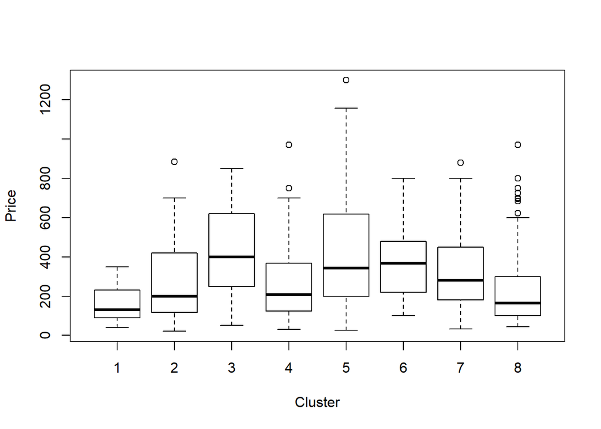

```r
boxplot(amz_products_cls$avg_price ~ as.factor(amz_products_cls$cluster_ecl), xlab="Cluster", ylab="Price")
```

#### In addition, we compare clusters based on the variable that did not participate in clustering - customer rating. As we saw previously, generally the majority of products tend to have high ratings. But clustering allowed to identify the groups with less favorable ratings - cluster 6, cluster 4, cluster 1, cluster 8. So it looks like that features, brand, and price are useful not only for creating distinct clusters but also for predicting problematic clusters.

```r
#Rating differences among clusters
tapply(amz_products_cls$avg_rating, sub_grp, mean)
```

```
##        1        2        3        4        5        6        7        8
## 3.777842 3.970401 4.059933 3.840446 4.055544 3.688402 4.043900 3.893372
```

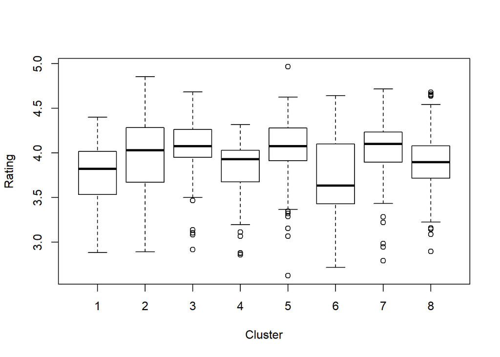

```r
boxplot(amz_products_cls$avg_rating ~ as.factor(amz_products_cls$cluster_ecl), xlab="Cluster", ylab="Rating")
```